# XGBoost with parameter tuning

tinker wang

2018年7月22日

# 1 摘要

# 2 介绍

# 3 导入和探索数据

## 3.1 导入需要的R包和读取数据

```r
library(readr)
library(knitr)
library(ggplot2)
library(dplyr)
library(corrplot)
library(caret)
library(gridExtra)
library(scales)
library(Rmisc)
library(ggrepel)
library(randomForest)
library(psych)
library(xgboost)
```

```r
train = readr::read_csv(file = "E:/DataScience/kaggle_proj/pro_HousePrice/data/train.csv", col_names = TRUE)
test = readr::read_csv(file = "E:/DataScience/kaggle_proj/pro_HousePrice/data/test.csv", col_names = TRUE)
```

```r
con = DBI::dbConnect(odbc::odbc(),
                     Driver = "SQL Server",
                     Server = "WANGZF-PC",
                     Database = "tinker",
                     UID = "tinker.wang",
                     # UID = rstudioapi::askForPassword("Database User"),
                     PWD = "alvin123",
                     # PWD = rstudioapi::askForPassword("SQL Server Database password"),
                     Port = 1433)
```

## 3.2 数据维度以及结构

```r
dim(train)
```

```
## [1] 1460   81
```

```r
str(train[, c(1:10, 81)])
```

```
## Classes 'tbl_df', 'tbl' and 'data.frame':    1460 obs. of  11 variables:
##  $ Id         : int  1 2 3 4 5 6 7 8 9 10 ...
##  $ MSSubClass : int  60 20 60 70 60 50 20 60 50 190 ...
##  $ MSZoning   : chr  "RL" "RL" "RL" "RL" ...
##  $ LotFrontage: int  65 80 68 60 84 85 75 NA 51 50 ...
##  $ LotArea    : int  8450 9600 11250 9550 14260 14115 10084 10382 6120 7420 ...
##  $ Street     : chr  "Pave" "Pave" "Pave" "Pave" ...
##  $ Alley      : chr  NA NA NA NA ...
##  $ LotShape   : chr  "Reg" "Reg" "IR1" "IR1" ...
##  $ LandContour: chr  "Lvl" "Lvl" "Lvl" "Lvl" ...
##  $ Utilities  : chr  "AllPub" "AllPub" "AllPub" "AllPub" ...
##  $ SalePrice  : int  208500 181500 223500 140000 250000 143000 307000 200000 129900 118000 ...
```

```r
train$Id = NULL
test_labels = test$Id
test$Id = NULL
test$SalePrice = NA
all =  rbind(train, test)
dim(all)
```

```
## [1] 2919   80
```

```r
head(all)
```

```
## # A tibble: 6 x 80
##   MSSubClass MSZoning LotFrontage LotArea Street Alley LotShape
##        <int> <chr>          <int>   <int> <chr>  <chr> <chr>
## 1         60 RL                65    8450 Pave   <NA>  Reg
## 2         20 RL                80    9600 Pave   <NA>  Reg
## 3         60 RL                68   11250 Pave   <NA>  IR1
## 4         70 RL                60    9550 Pave   <NA>  IR1
## 5         60 RL                84   14260 Pave   <NA>  IR1
## 6         50 RL                85   14115 Pave   <NA>  IR1
## # ... with 73 more variables: LandContour <chr>, Utilities <chr>,
## #   LotConfig <chr>, LandSlope <chr>, Neighborhood <chr>,
## #   Condition1 <chr>, Condition2 <chr>, BldgType <chr>, HouseStyle <chr>,
## #   OverallQual <int>, OverallCond <int>, YearBuilt <int>,
## #   YearRemodAdd <int>, RoofStyle <chr>, RoofMatl <chr>,
## #   Exterior1st <chr>, Exterior2nd <chr>, MasVnrType <chr>,
## #   MasVnrArea <int>, ExterQual <chr>, ExterCond <chr>, Foundation <chr>,
## #   BsmtQual <chr>, BsmtCond <chr>, BsmtExposure <chr>,
## #   BsmtFinType1 <chr>, BsmtFinSF1 <int>, BsmtFinType2 <chr>,
## #   BsmtFinSF2 <int>, BsmtUnfSF <int>, TotalBsmtSF <int>, Heating <chr>,
## #   HeatingQC <chr>, CentralAir <chr>, Electrical <chr>, `1stFlrSF` <int>,
## #   `2ndFlrSF` <int>, LowQualFinSF <int>, GrLivArea <int>,
## #   BsmtFullBath <int>, BsmtHalfBath <int>, FullBath <int>,
## #   HalfBath <int>, BedroomAbvGr <int>, KitchenAbvGr <int>,
## #   KitchenQual <chr>, TotRmsAbvGrd <int>, Functional <chr>,
## #   Fireplaces <int>, FireplaceQu <chr>, GarageType <chr>,
## #   GarageYrBlt <int>, GarageFinish <chr>, GarageCars <int>,
## #   GarageArea <int>, GarageQual <chr>, GarageCond <chr>,
## #   PavedDrive <chr>, WoodDeckSF <int>, OpenPorchSF <int>,
## #   EnclosedPorch <int>, `3SsnPorch` <int>, ScreenPorch <int>,
## #   PoolArea <int>, PoolQC <chr>, Fence <chr>, MiscFeature <chr>,
## #   MiscVal <int>, MoSold <int>, YrSold <int>, SaleType <chr>,
## #   SaleCondition <chr>, SalePrice <int>
```

```r
dim(train)
```

```
## [1] 1460   80
```

```r
dim(test)
```

```
## [1] 1459   80
```

# 4 对一些重要的变量进行探索性分析

## 4.1 响应变量SalePrice的探索性分析

```r
sapply(all %>% select(SalePrice), function(x) sum(is.na(x)))
```

```
## SalePrice
##      1459
```

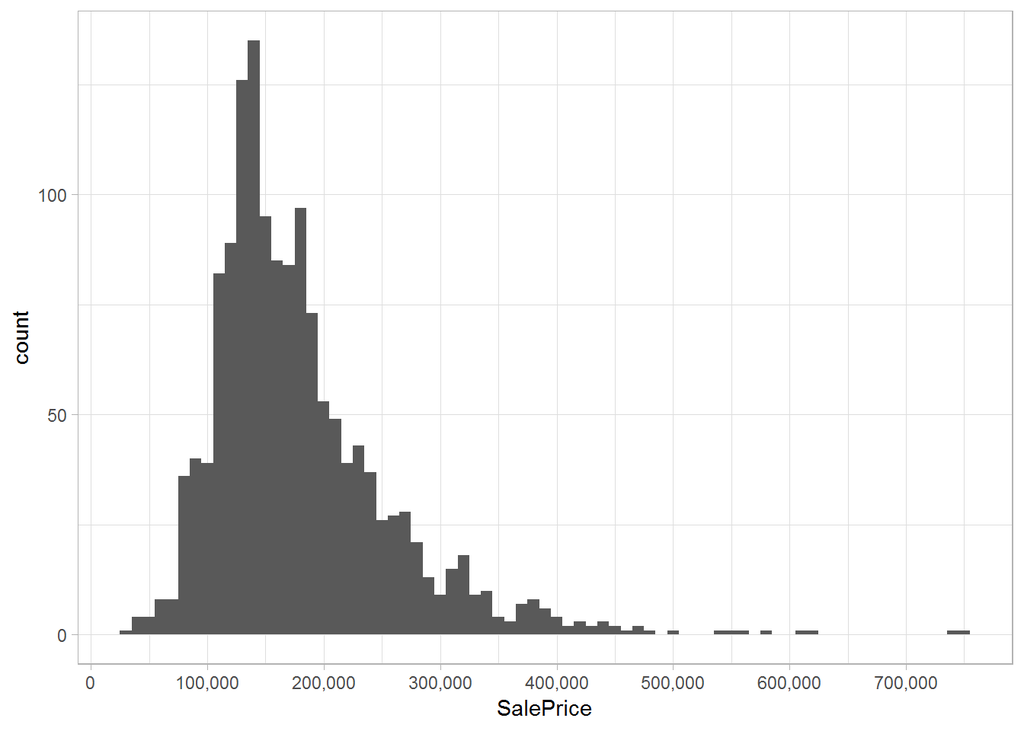

```r
ggplot(data = all[!is.na(all$SalePrice), ], mapping = aes(x = SalePrice)) +
    geom_histogram(binwidth = 10000) +
    scale_x_continuous(breaks = seq(0, 800000, 100000), labels = comma) +
    theme_light()
```

```r
summary(all$SalePrice)
```

```
##    Min. 1st Qu.  Median    Mean 3rd Qu.    Max.    NA's
##   34900  129975  163000  180921  214000  755000    1459
```

```r
describe(all$SalePrice)
```

```
##    vars    n     mean      sd median  trimmed     mad   min    max  range
## X1    1 1460 180921.2 79442.5 163000 170783.3 56338.8 34900 755000 720100
##    skew kurtosis      se
## X1 1.88      6.5 2079.11
```

## 4.2 自变量的探索性分析

### 4.2.1 自变量和SalePrice的相关关系

```r
numericVars = which(sapply(all, is.numeric))
numericVarNames = names(numericVars)
numericVarNames
```

```
##  [1] "MSSubClass"    "LotFrontage"   "LotArea"       "OverallQual"
##  [5] "OverallCond"   "YearBuilt"     "YearRemodAdd"  "MasVnrArea"
##  [9] "BsmtFinSF1"    "BsmtFinSF2"    "BsmtUnfSF"     "TotalBsmtSF"
## [13] "1stFlrSF"      "2ndFlrSF"      "LowQualFinSF"  "GrLivArea"
## [17] "BsmtFullBath"  "BsmtHalfBath"  "FullBath"      "HalfBath"
## [21] "BedroomAbvGr"  "KitchenAbvGr"  "TotRmsAbvGrd"  "Fireplaces"
## [25] "GarageYrBlt"   "GarageCars"    "GarageArea"    "WoodDeckSF"
## [29] "OpenPorchSF"   "EnclosedPorch" "3SsnPorch"     "ScreenPorch"
## [33] "PoolArea"      "MiscVal"       "MoSold"        "YrSold"
## [37] "SalePrice"
```

```r
cat("数值型变量的个数是:", length(numericVars))
```

```
## 数值型变量的个数是: 37
```

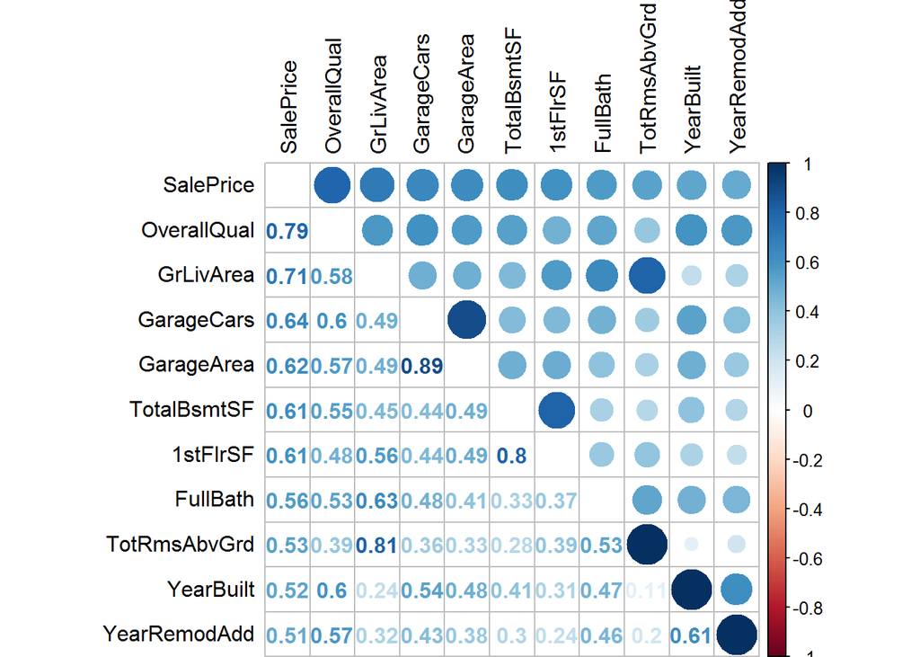

```r
all_numVar = all[, numericVars]
cor_numVar = cor(all_numVar, use = "pairwise.complete.obs")
cor_sorted = as.matrix(sort(cor_numVar[, "SalePrice"], decreasing = TRUE))

CorHigh = names(which(apply(cor_sorted, 1, function(x) {abs(x) > 0.5})))
cor_numVar = cor_numVar[CorHigh, CorHigh]
corrplot.mixed(cor_numVar, tl.col = "black", tl.pos = "lt")
```

### 4.2.2 分析OverallQual和SalePrice的相关关系

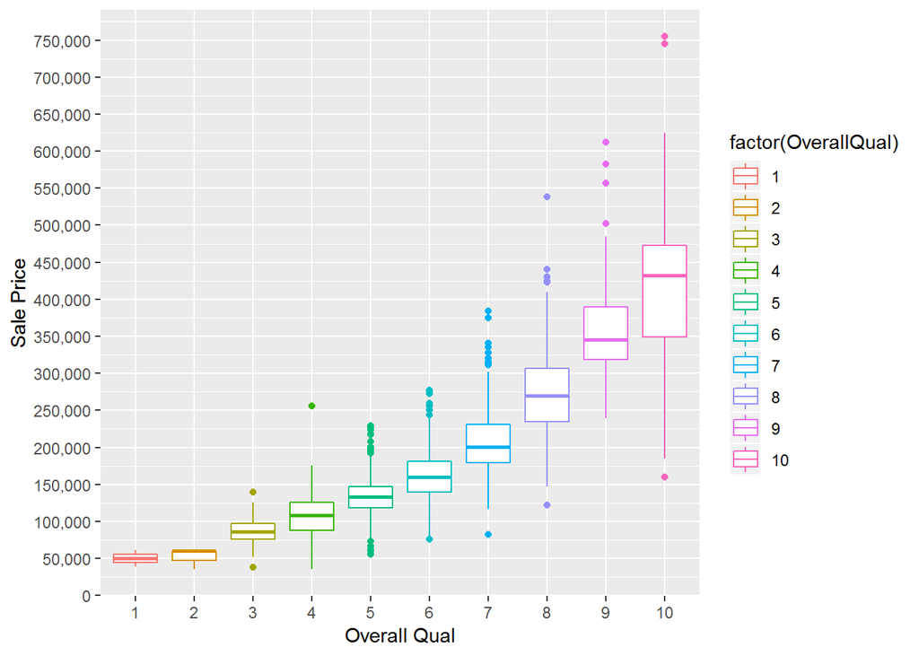

```r
ggplot(data = all[!is.na(all$SalePrice), ], mapping = aes(x = factor(OverallQual), y = SalePrice, colour = factor(OverallQual))) +
    geom_boxplot() +
    xlab("Overall Qual") +
    ylab("Sale Price") +
    scale_y_continuous(breaks = seq(0, 800000, by = 50000), labels = comma)
```

### 4.2.3 分析GrLivArea和SalePrice的相关关系

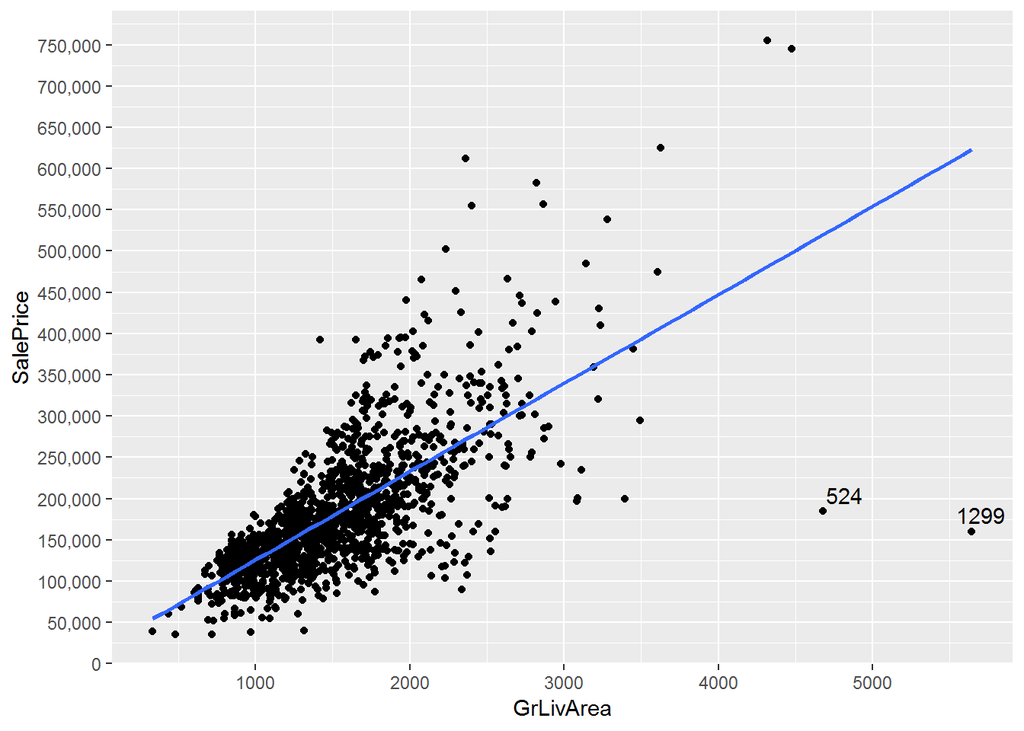

```r
ggplot(data = all[!is.na(all$SalePrice), ], mapping = aes(x = GrLivArea, y = SalePrice)) +
    geom_point() +
    geom_smooth(method = "lm", se = FALSE, aes(group = 1)) +
    scale_y_continuous(breaks = seq(0, 800000, by = 50000), label = comma) +
    geom_text_repel(mapping = aes(label = ifelse(all$GrLivArea[!is.na(all$SalePrice)] > 4500, rownames(all), "")))
```

```r
all[c(524, 1299), c("SalePrice", "GrLivArea", "OverallQual")]
```

```
## # A tibble: 2 x 3
##   SalePrice GrLivArea OverallQual
##       <int>     <int>       <int>
## 1    184750      4676          10
## 2    160000      5642          10
```

# 5 Missing Values, label encoding, and factorizing variables

## 5.1 缺失值检查

```r
NAcol <- which(colSums(is.na(all)) > 0)
sort(colSums(sapply(all[NAcol], is.na)), decreasing = TRUE)
```

```
##       PoolQC  MiscFeature        Alley        Fence    SalePrice
##         2909         2814         2721         2348         1459
##  FireplaceQu  LotFrontage  GarageYrBlt GarageFinish   GarageQual
##         1420          486          159          159          159
##   GarageCond   GarageType     BsmtCond BsmtExposure     BsmtQual
##          159          157           82           82           81
## BsmtFinType2 BsmtFinType1   MasVnrType   MasVnrArea     MSZoning
##           80           79           24           23            4
##    Utilities BsmtFullBath BsmtHalfBath   Functional  Exterior1st
##            2            2            2            2            1
##  Exterior2nd   BsmtFinSF1   BsmtFinSF2    BsmtUnfSF  TotalBsmtSF
##            1            1            1            1            1
##   Electrical  KitchenQual   GarageCars   GarageArea     SaleType
##            1            1            1            1            1
```

```r
cat('There are', length(NAcol), 'columns with missing values')
```

```
## There are 35 columns with missing values
```

## 5.2 缺失值检查及填充

### 5.2.1 Pool相关的变量

- **检查Pool相关的变量缺失情况**

```r
PoolNaCols = all %>%
    select(starts_with("Pool")) %>%
    sapply(function(x) is.na(x)) %>%
    colSums() %>%
    sort(decreasing = TRUE)
PoolNaCols
```

```
##   PoolQC PoolArea
##     2909        0
```

**Pool Quality 和 PoolArea**

PoolQC变量是缺失值最多的变量，变量的观测值含义如下：

PoolQC: 泳池质量

```
   Ex   Excellent
   Gd   Good
   TA   Average/Typical
   Fa   Fair
   NA   No Pool
```

- 很明显PoolQC为缺失值代表着这些房子没有泳池，因此，将这些缺失值填充为“None”，并且可以看到只有很少的房子是带有游泳池的，这很符合现实情况：

```r
all$PoolQC[is.na(all$PoolQC)] = 'None'
```

- 泳池的质量应该是一个有序的类别型变量，因此这里将该变量重编码为有序类别变量：

```r
Qualities = c('None' = 0, 'Po' = 1, 'Fa' = 2, 'TA' = 3, 'Gd' = 4, 'Ex' = 5)
all$PoolQC = as.integer(revalue(all$PoolQC, Qualities))
table(all$PoolQC)
```

```
##
##    0    2    4    5
## 2909    2    4    4
```

PoolArea: 泳池面积

- 和PoolQC相关的一个泳池变量为PoolArea，泳池的面积明显也直接影响着泳池质量评分的高低，在数据中可以看到有3个明显的观测值的泳池面积不为零，而泳池的质量却为零，明显这是不合理的，因为PoolQC=0代表着该房子没有泳池，因此根据PoolArea的大小和OverallQual的值给这三个房子的PoolQC进行合理的评分：

```r
all[all$PoolArea > 0 & all$PoolQC == 0, c('PoolArea', 'PoolQC', 'OverallQual')]
```

```
## # A tibble: 3 x 3
##   PoolArea PoolQC OverallQual
##      <int>  <int>       <int>
## 1      368      0           4
## 2      444      0           6
## 3      561      0           3
```

```r
all$PoolQC[2421] = 2
all$PoolQC[2504] = 3
all$PoolQC[2600] = 2
```

- 填充后的PoolQC变量：

```r
table(all$PoolQC)
```

```
##
##    0    2    3    4    5
## 2906    4    1    4    4
```

**Please return to the 5.2 Tabs menu to select other (groups of) variables**

### 5.2.2 Miscellaneous Feature

```
   Elev Elevator(电梯)
   Gar2 2nd Garage(车库) (if not described in garage section)
   Othr Other
   Shed Shed(棚子) (over 100 SF)
   TenC Tennis Court(网球场)
   NA   None
```

```r
all$MiscFeature[is.na(all$MiscFeature)] = "None"
all$MiscFeature = all$MiscFeature %>% as.factor()
table(all$MiscFeature)
```

```
##
## Gar2 None Othr Shed TenC
##    5 2814    4   95    1
```

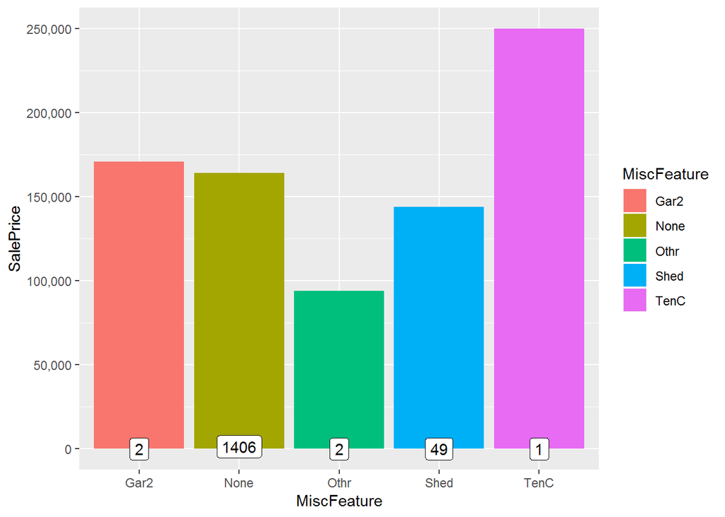

```r
ggplot(data = all[!is.na(all$SalePrice), ], mapping = aes(x = MiscFeature, y = SalePrice)) +
    geom_bar(stat = "summary", fun.y = "median", mapping = aes(fill = MiscFeature)) +
    scale_y_continuous(breaks = seq(0, 800000, by = 50000), labels = comma) +
    geom_label(stat = "count", mapping = aes(label = ..count.., y = ..count..))
```

**Please return to the 5.2 Tabs menu to select other (groups of) variables**

### 5.2.3 Alley

**Type of alley access to property**

在Alley变量中有2721个缺失值. 这个变量不是有序变量，所以Alley转换为因子类型变量：

```
   Grvl Gravel(碎石)
   Pave Paved(铺砌)
   NA   No alley access
```

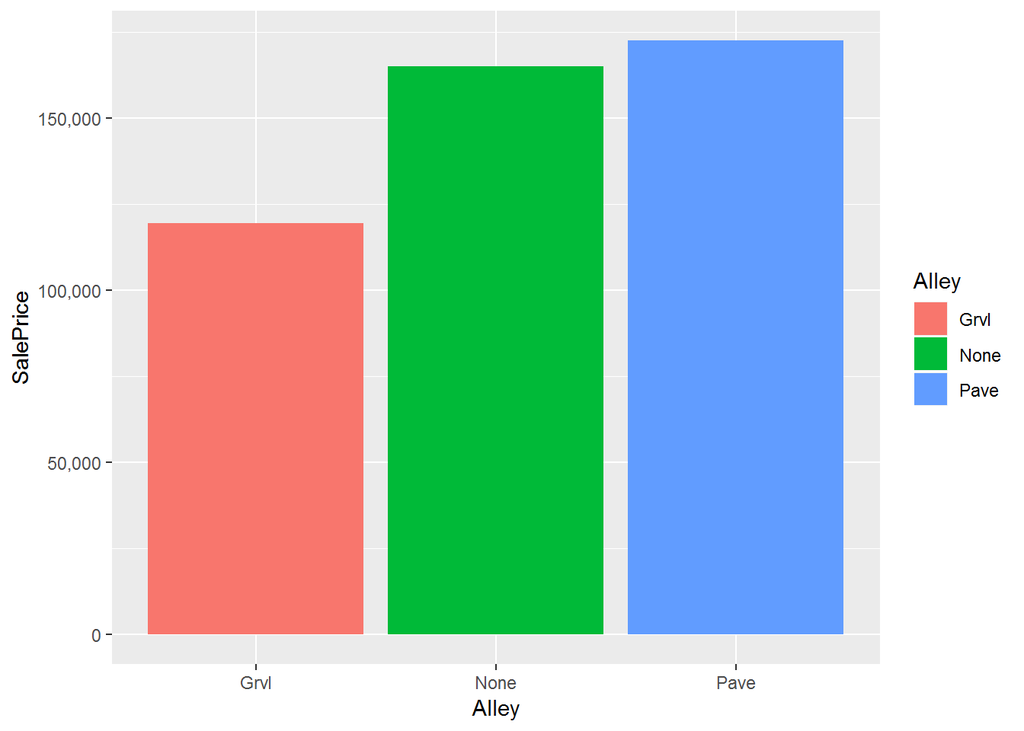

```r
all$Alley[is.na(all$Alley)] = "None"
all$Alley = all$Alley %>%
    as.factor()

ggplot(data = all[!is.na(all$SalePrice), ], mapping = aes(x = Alley, y = SalePrice)) +
    geom_bar(stat = "summary", fun.y = "median", mapping = aes(fill = Alley)) +
    scale_y_continuous(breaks = seq(0, 200000, by = 50000), label = comma)
```

```r
table(all$Alley)
```

```
##
## Grvl None Pave
##  120 2721   78
```

**Please return to the 5.2 Tabs menu to select other (groups of) variables**

### 5.2.4 Fence

**Fence quality**

Fence中有2348个缺失值. 并且该变量似乎是有序类别型变量:

```
   GdPrv    Good Privacy
   MnPrv    Minimum Privacy
   GdWo     Good Wood
   MnWw     Minimum Wood/Wire
   NA       No Fence
```

```r
all$Fence[is.na(all$Fence)] = "None"
all$Fence %>% table()
```

```
## .
## GdPrv  GdWo MnPrv  MnWw  None
##   118   112   329    12  2348
```

```r
# detach("package:plyr", unload = TRUE)
# conflicts()
all[!is.na(all$SalePrice), ] %>%
    group_by(as.factor(Fence)) %>%
    dplyr::summarise(medians = median(SalePrice), counts = n())
```

```
## # A tibble: 5 x 3
##   `as.factor(Fence)` medians counts
##   <fct>                <dbl>  <int>
## 1 GdPrv              167500.     59
## 2 GdWo               138750.     54
## 3 MnPrv              137450.    157
## 4 MnWw               130000.     11
## 5 None               173000.   1179
```

由于不同的篱笆质量下，房价中位数没有太大的差别，即对于房价来说，没有好的篱笆和坏的篱笆之分，因此，这里认为Fence不是有序类别型变量，只是普通的因子型变量：

```r
all$Fence = as.factor(all$Fence)
```

**Please return to the 5.2 Tabs menu to select other (groups of) variables**

### 5.2.5 Fireplace(壁炉)

**FireplaceQu(壁炉质量)和Fireplaces(壁炉质量)**

在FireplaceQu中有1420个缺失值，Fireplaces没有缺失值.

**FireplaceQu**

The number of NAs in FireplaceQu matches the number of houses with 0 fireplaces. This means that I can safely replace the NAs in FireplaceQu with ‘no fireplace’. The values are ordinal, and I can use the Qualities vector that I have already created for the Pool Quality. Values:

FireplaceQu中的缺失值数量正好是Fireplaces=0的观测值数量，因此，可以将FireplaceQu中的缺失观测填充为“None”，并且FireplaceQu是有序类别型变量，根据PoolQC中的编码向量Qualities将FireplaceQu重新编码为有序因子:

```
   Ex   Excellent - Exceptional Masonry Fireplace
   Gd   Good - Masonry Fireplace in main level
   TA   Average - Prefabricated Fireplace in main living area or Masonry Fireplace in basement
   Fa   Fair - Prefabricated Fireplace in basement
   Po   Poor - Ben Franklin Stove
   NA   No Fireplace
```

```r
all$FireplaceQu[is.na(all$FireplaceQu)] = "None"
all$FireplaceQu = as.integer(revalue(all$FireplaceQu, Qualities))
all$FireplaceQu %>% table()
```

```
## .
##    0    1    2    3    4    5
## 1420   46   74  592  744   43
```

**Fireplaces**

Fireplaces是一个整数型变量，且没有缺失值：

```r
all$Fireplaces %>% table()
```

```
## .
##    0    1    2    3    4
## 1420 1268  219   11    1
```

```r
all$Fireplaces %>% table() %>% sum()
```

```
## [1] 2919
```

**Please return to the 5.2 Tabs menu to select other (groups of) variables**

### 5.2.6 Lot variables

- LotForntage: 有486个缺失值
- LotShape：无缺失值
- LotConfig：无缺失值

**LotFrontage: Linear feet of street connected to property**

LotFrontage与Neighborhood有很强的相关性, 因此对LotFrontage中缺失的观测值在相应的Neighborhood下的中位数进行填充:

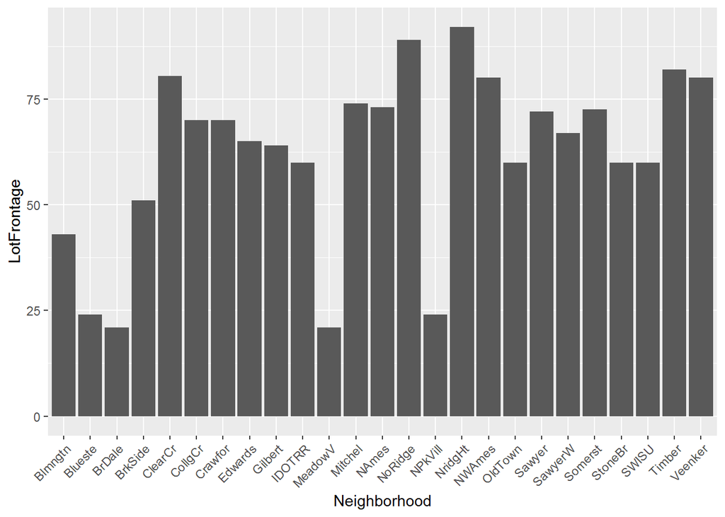

```r
ggplot(data = all[!is.na(all$LotFrontage),], aes(x = as.factor(Neighborhood), y = LotFrontage)) +
        geom_bar(stat = 'summary', fun.y = "median") +
        theme(axis.text.x = element_text(angle = 45, hjust = 1)) +
    xlab("Neighborhood")
```

```r
med = all %>%
    group_by(Nei = as.factor(Neighborhood)) %>%
    dplyr::summarise(medians = median(LotFrontage, na.rm = TRUE))
all = all %>% mutate(id = rownames(all))
missing = all %>%
    select(c(id, LotFrontage, Neighborhood)) %>%
    filter(is.na(LotFrontage)) %>%
    left_join(med, by = c("Neighborhood" = "Nei"))
for(i in  missing$id) {
    all$LotFrontage[all$id == i] = missing$medians[missing$id == i]
}
all = all %>% select(-id)
# for (i in 1:nrow(all)){
#         if(is.na(all$LotFrontage[i])){
#                all$LotFrontage[i] = as.integer(median(all$LotFrontage[all$Neighborhood == all$Neighborhood[i]], na.rm = TRUE))
#         }
# }
```

```r
all %>%
    filter(is.na(LotFrontage))
```

```
## # A tibble: 0 x 80
## # ... with 80 variables: MSSubClass <int>, MSZoning <chr>,
## #   LotFrontage <dbl>, LotArea <int>, Street <chr>, Alley <fct>,
## #   LotShape <chr>, LandContour <chr>, Utilities <chr>, LotConfig <chr>,
## #   LandSlope <chr>, Neighborhood <chr>, Condition1 <chr>,
## #   Condition2 <chr>, BldgType <chr>, HouseStyle <chr>, OverallQual <int>,
## #   OverallCond <int>, YearBuilt <int>, YearRemodAdd <int>,
## #   RoofStyle <chr>, RoofMatl <chr>, Exterior1st <chr>, Exterior2nd <chr>,
## #   MasVnrType <chr>, MasVnrArea <int>, ExterQual <chr>, ExterCond <chr>,
## #   Foundation <chr>, BsmtQual <chr>, BsmtCond <chr>, BsmtExposure <chr>,
## #   BsmtFinType1 <chr>, BsmtFinSF1 <int>, BsmtFinType2 <chr>,
## #   BsmtFinSF2 <int>, BsmtUnfSF <int>, TotalBsmtSF <int>, Heating <chr>,
## #   HeatingQC <chr>, CentralAir <chr>, Electrical <chr>, `1stFlrSF` <int>,
## #   `2ndFlrSF` <int>, LowQualFinSF <int>, GrLivArea <int>,
## #   BsmtFullBath <int>, BsmtHalfBath <int>, FullBath <int>,
## #   HalfBath <int>, BedroomAbvGr <int>, KitchenAbvGr <int>,
## #   KitchenQual <chr>, TotRmsAbvGrd <int>, Functional <chr>,
## #   Fireplaces <int>, FireplaceQu <int>, GarageType <chr>,
## #   GarageYrBlt <int>, GarageFinish <chr>, GarageCars <int>,
## #   GarageArea <int>, GarageQual <chr>, GarageCond <chr>,
## #   PavedDrive <chr>, WoodDeckSF <int>, OpenPorchSF <int>,
## #   EnclosedPorch <int>, `3SsnPorch` <int>, ScreenPorch <int>,
## #   PoolArea <int>, PoolQC <dbl>, Fence <fct>, MiscFeature <fct>,
## #   MiscVal <int>, MoSold <int>, YrSold <int>, SaleType <chr>,
## #   SaleCondition <chr>, SalePrice <int>
```

**LotShape: General shape of property**

没有缺失值，并且是一个有序类别型变量：

```
   Reg  Regular
   IR1  Slightly irregular
   IR2  Moderately Irregular
   IR3  Irregular
```

```r
all$LotShape<-as.integer(revalue(all$LotShape, c('IR3' = 0, 'IR2' = 1, 'IR1' = 2, 'Reg' = 3)))
table(all$LotShape)
```

```
##
##    0    1    2    3
##   16   76  968 1859
```

```r
sum(table(all$LotShape))
```

```
## [1] 2919
```

**LotConfig: Lot configuration**

没有缺失值，且不是有序变量：

```
   Inside   Inside lot
   Corner   Corner lot
   CulDSac  Cul-de-sac
   FR2  Frontage on 2 sides of property
   FR3  Frontage on 3 sides of property
```

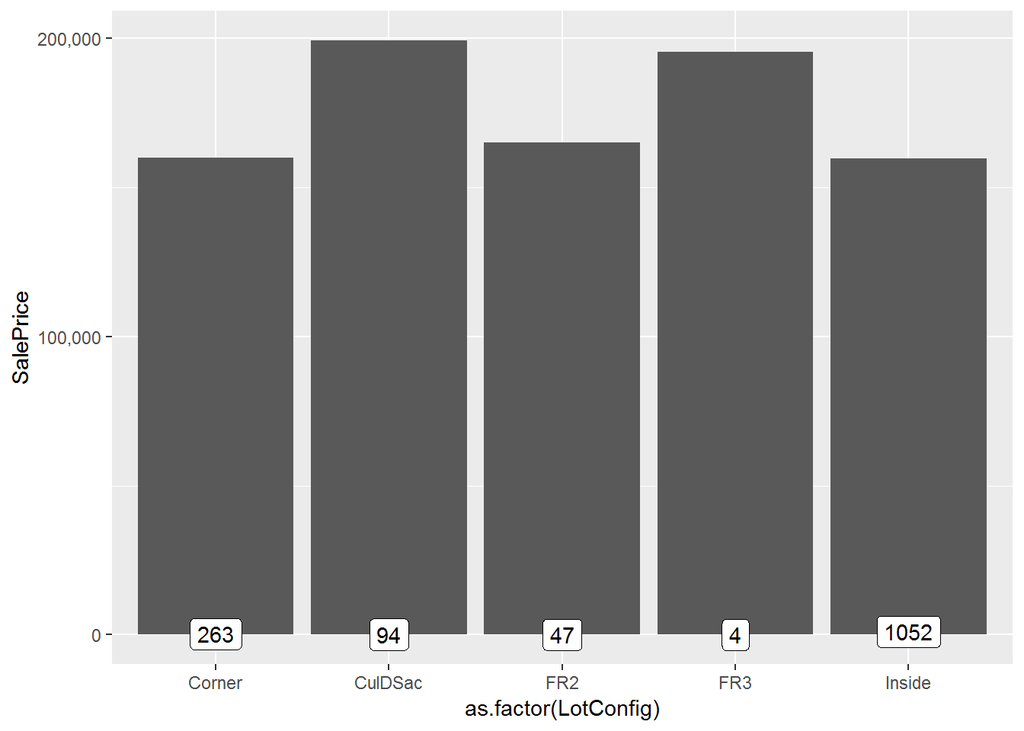

```r
ggplot(all[!is.na(all$SalePrice), ], aes(x = as.factor(LotConfig), y = SalePrice)) +
    geom_bar(stat = 'summary', fun.y = "median")+
    scale_y_continuous(breaks = seq(0, 800000, by = 100000), labels = comma) +
    geom_label(stat = "count", aes(label = ..count.., y = ..count..))
```

```r
all$LotConfig <- as.factor(all$LotConfig)
table(all$LotConfig)
```

```
##
##  Corner CulDSac     FR2     FR3  Inside
##     511     176      85      14    2133
```

```r
sum(table(all$LotConfig))
```

```
## [1] 2919
```

**Please return to the 5.2 Tabs menu to select other (groups of) variables**

### 5.2.7 Garage(车库)变量

**有7个和车库有关的变量，变量观测值缺失情况：**

```r
GarageNacols = all %>%
    select(starts_with("Garage")) %>%
    sapply(function(x) is.na(x)) %>%
    colSums() %>%
    sort(decreasing = TRUE)
GarageNacols
```

```
##  GarageYrBlt GarageFinish   GarageQual   GarageCond   GarageType
##          159          159          159          159          157
##   GarageCars   GarageArea
##            1            1
```

```r
head(all %>% select(starts_with("Garage")))
```

```
## # A tibble: 6 x 7
##   GarageType GarageYrBlt GarageFinish GarageCars GarageArea GarageQual
##   <chr>            <int> <chr>             <int>      <int> <chr>
## 1 Attchd            2003 RFn                   2        548 TA
## 2 Attchd            1976 RFn                   2        460 TA
## 3 Attchd            2001 RFn                   2        608 TA
## 4 Detchd            1998 Unf                   3        642 TA
## 5 Attchd            2000 RFn                   3        836 TA
## 6 Attchd            1993 Unf                   2        480 TA
## # ... with 1 more variable: GarageCond <chr>
```

- **GarageYrBlt:**

对于GarageYrBlt，显然应该和YearBuilt变量有相同的值，因为车库基本是在房子建造的时候建的(也有可能是后来在别的地方新建的)：

```r
all$GarageYrBlt[is.na(all$GarageYrBlt)] = all$YearBuilt[is.na(all$GarageYrBlt)]
```

对于车库变量中的字符型变量，NA代表着没有车库，现在来分析一下GarageType和其他三个有159个缺失值的变量是否有直接的关系：

```r
#check if all 157 NAs are the same observations among the variables with 157/159 NAs
length(which(is.na(all$GarageType) & is.na(all$GarageFinish) & is.na(all$GarageCond) & is.na(all$GarageQual)))
```

```
## [1] 157
```

```r
#Find the 2 additional NAs
kable(all[!is.na(all$GarageType) & is.na(all$GarageFinish), c('GarageCars', 'GarageArea', 'GarageType', 'GarageCond', 'GarageQual', 'GarageFinish')])
```

| GarageCars | GarageArea | GarageType | GarageCond | GarageQual | GarageFinish |
| --- | --- | --- | --- | --- | --- |
| 1 | 360 | Detchd | NA | NA | NA |
| NA | NA | Detchd | NA | NA | NA |

GarageType变量中缺失的157个值在GarageCondition, GarageQuanlity, GarageFinish中也同时都缺失。不同的是第2127和2577个房子，第2127个房子似乎是有车库的，而2577个房子没有车库，所以应该有158个房子没有车库，因此，需要对第2127个房子的其他变量进行填充，这里用每个变量的众数来进行缺失值填充GarageCond, GarageQual和GarageFinish：

```r
#Imputing modes.
all$GarageCond[2127] <- names(sort(-table(all$GarageCond)))[1]
all$GarageQual[2127] <- names(sort(-table(all$GarageQual)))[1]
all$GarageFinish[2127] <- names(sort(-table(all$GarageFinish)))[1]

#display "fixed" house
kable(all[2127, c('GarageYrBlt', 'GarageCars', 'GarageArea', 'GarageType', 'GarageCond', 'GarageQual', 'GarageFinish')])
```

| GarageYrBlt | GarageCars | GarageArea | GarageType | GarageCond | GarageQual | GarageFinish |
| --- | --- | --- | --- | --- | --- | --- |
| 1910 | 1 | 360 | Detchd | TA | TA | Unf |

现在车库变量的缺失情况是：

```r
GarageNacols = all %>%
    select(starts_with("Garage")) %>%
    sapply(function(x) is.na(x)) %>%
    colSums() %>%
    sort(decreasing = TRUE)
GarageNacols
```

```
## GarageFinish   GarageQual   GarageCond   GarageType   GarageCars
##          158          158          158          157            1
##   GarageArea  GarageYrBlt
##            1            0
```

- **GarageCars and GarageArea: 容纳车库的体积和车库的面积**

这两个变量都只有一个缺失值，都是第2577号房子的缺失值，GarageType是“detached”且其他变量都是缺失，因此，可以判断这个房子没有车库：

```r
#fixing 3 values for house 2577
all$GarageCars[2577] <- 0
all$GarageArea[2577] <- 0
all$GarageType[2577] <- NA

#check if NAs of the character variables are now all 158
length(which(is.na(all$GarageType) & is.na(all$GarageFinish) & is.na(all$GarageCond) & is.na(all$GarageQual)))
```

```
## [1] 158
```

```r
GarageNacols = all %>%
    select(starts_with("Garage")) %>%
    sapply(function(x) is.na(x)) %>%
    colSums() %>%
    sort(decreasing = TRUE)
GarageNacols
```

```
##   GarageType GarageFinish   GarageQual   GarageCond  GarageYrBlt
##          158          158          158          158            0
##   GarageCars   GarageArea
##            0            0
```

现在只剩下四个字符型车库变量有缺失值，并且都同时缺失158个，说明这158个房子就是没有车库，因此将他们都填充为无车库对应的值即可。

- **GarageType: 车库位置**

这个变量明显不是有序变量，因此只需要将其转换为因子型变量：

```
   2Types   More than one type of garage
   Attchd   Attached to home
   Basment  Basement Garage
   BuiltIn  Built-In (Garage part of house - typically has room above garage)
   CarPort  Car Port
   Detchd   Detached from home
   NA   No Garage
```

```r
all$GarageType[is.na(all$GarageType)] = 'No Garage'
all$GarageType = as.factor(all$GarageType)
table(all$GarageType)
```

```
##
##    2Types    Attchd   Basment   BuiltIn   CarPort    Detchd No Garage
##        23      1723        36       186        15       778       158
```

**GarageFinish: 车库的内部装饰**

这个变量是有序类别型变量：

```
   Fin  Finished
   RFn  Rough Finished
   Unf  Unfinished
   NA   No Garage
```

```r
all$GarageFinish[is.na(all$GarageFinish)] = 'None'
Finish = c('None' = 0, 'Unf' = 1, 'RFn' = 2, 'Fin' = 3)

all$GarageFinish = as.integer(revalue(all$GarageFinish, Finish))
table(all$GarageFinish)
```

```
##
##    0    1    2    3
##  158 1231  811  719
```

**GarageQual: Garage quality**

有序类别型变量：

```
   Ex   Excellent
   Gd   Good
   TA   Typical/Average
   Fa   Fair
   Po   Poor
   NA   No Garage
```

```r
all$GarageQual[is.na(all$GarageQual)] = 'None'
all$GarageQual = as.integer(revalue(all$GarageQual, Qualities))
table(all$GarageQual)
```

```
##
##    0    1    2    3    4    5
##  158    5  124 2605   24    3
```

**GarageCond: Garage condition**

有序类别型变量：

```
   Ex   Excellent
   Gd   Good
   TA   Typical/Average
   Fa   Fair
   Po   Poor
   NA   No Garage
```

```r
all$GarageCond[is.na(all$GarageCond)] = 'None'
all$GarageCond = as.integer(revalue(all$GarageCond, Qualities))
table(all$GarageCond)
```

```
##
##    0    1    2    3    4    5
##  158   14   74 2655   15    3
```

```r
GarageNacols = all %>%
    select(starts_with("Garage")) %>%
    sapply(function(x) is.na(x)) %>%
    colSums() %>%
    sort(decreasing = TRUE)
GarageNacols
```

```
##   GarageType  GarageYrBlt GarageFinish   GarageCars   GarageArea
##            0            0            0            0            0
##   GarageQual   GarageCond
##            0            0
```

**Please return to the 5.2 Tabs menu to select other (groups of) variables**

### 5.2.8 Basement(地下室)变量

**共有11个关于Basement的变量**

```r
BasementCols = all %>%
    select(starts_with("Bs"), TotalBsmtSF)
BasementCols
```

```
## # A tibble: 2,919 x 11
##    BsmtQual BsmtCond BsmtExposure BsmtFinType1 BsmtFinSF1 BsmtFinType2
##    <chr>    <chr>    <chr>        <chr>             <int> <chr>
##  1 Gd       TA       No           GLQ                 706 Unf
##  2 Gd       TA       Gd           ALQ                 978 Unf
##  3 Gd       TA       Mn           GLQ                 486 Unf
##  4 TA       Gd       No           ALQ                 216 Unf
##  5 Gd       TA       Av           GLQ                 655 Unf
##  6 Gd       TA       No           GLQ                 732 Unf
##  7 Ex       TA       Av           GLQ                1369 Unf
##  8 Gd       TA       Mn           ALQ                 859 BLQ
##  9 TA       TA       No           Unf                   0 Unf
## 10 TA       TA       No           GLQ                 851 Unf
## # ... with 2,909 more rows, and 5 more variables: BsmtFinSF2 <int>,
## #   BsmtUnfSF <int>, BsmtFullBath <int>, BsmtHalfBath <int>,
## #   TotalBsmtSF <int>
```

```r
BasementNacols = all %>%
    select(starts_with("Bs"), TotalBsmtSF) %>%
    sapply(function(x) is.na(x)) %>%
    colSums() %>%
    sort(decreasing = TRUE)
BasementNacols
```

```
##     BsmtCond BsmtExposure     BsmtQual BsmtFinType2 BsmtFinType1
##           82           82           81           80           79
## BsmtFullBath BsmtHalfBath   BsmtFinSF1   BsmtFinSF2    BsmtUnfSF
##            2            2            1            1            1
##  TotalBsmtSF
##            1
```

- **分析变量缺失的模式：**

```r
#check if all 79 NAs are the same observations among the variables with 80+ NAs
length(which(is.na(all$BsmtQual) & is.na(all$BsmtCond) & is.na(all$BsmtExposure) & is.na(all$BsmtFinType1) & is.na(all$BsmtFinType2)))
```

```
## [1] 79
```

```r
#Find the additional NAs; BsmtFinType1 is the one with 79 NAs
all[!is.na(all$BsmtFinType1) & (is.na(all$BsmtCond)|is.na(all$BsmtQual)|is.na(all$BsmtExposure)|is.na(all$BsmtFinType2)), c('BsmtQual', 'BsmtCond', 'BsmtExposure', 'BsmtFinType1', 'BsmtFinType2')]
```

```
## # A tibble: 9 x 5
##   BsmtQual BsmtCond BsmtExposure BsmtFinType1 BsmtFinType2
##   <chr>    <chr>    <chr>        <chr>        <chr>
## 1 Gd       TA       No           GLQ          <NA>
## 2 Gd       TA       <NA>         Unf          Unf
## 3 Gd       TA       <NA>         Unf          Unf
## 4 Gd       <NA>     Mn           GLQ          Rec
## 5 TA       <NA>     No           BLQ          Unf
## 6 <NA>     Fa       No           Unf          Unf
## 7 <NA>     TA       No           Unf          Unf
## 8 Gd       TA       <NA>         Unf          Unf
## 9 TA       <NA>     Av           ALQ          Unf
```

> 从上面分析发现的变量缺失模式可以看出，有79个房子的BsmtQual, BsmtCond, BsmtExposure, BsmtFinType1, BsmtFinType2同时缺失，说明这79个房子没有地下室。 对其他的几个缺失值，这里先用众数进行填充。

```r
#Imputing modes.
all$BsmtFinType2[333] = names(sort(-table(all$BsmtFinType2)))[1]
all$BsmtExposure[c(949, 1488, 2349)] = names(sort(-table(all$BsmtExposure)))[1]
all$BsmtCond[c(2041, 2186, 2525)] = names(sort(-table(all$BsmtCond)))[1]
all$BsmtQual[c(2218, 2219)] = names(sort(-table(all$BsmtQual)))[1]
```

```r
BasementNacols = all %>%
    select(starts_with("Bs"), TotalBsmtSF) %>%
    sapply(function(x) is.na(x)) %>%
    colSums() %>%
    sort(decreasing = TRUE)
BasementNacols
```

```
##     BsmtQual     BsmtCond BsmtExposure BsmtFinType1 BsmtFinType2
##           79           79           79           79           79
## BsmtFullBath BsmtHalfBath   BsmtFinSF1   BsmtFinSF2    BsmtUnfSF
##            2            2            1            1            1
##  TotalBsmtSF
##            1
```

- **对于上面的5个同时缺失的没有地下室的变量，进行填充和重新编码：**
- **BsmtQual: 地下室的高度**

有序类别型变量：

```
   Ex   Excellent (100+ inches)
   Gd   Good (90-99 inches)
   TA   Typical (80-89 inches)
   Fa   Fair (70-79 inches)
   Po   Poor (<70 inches
   NA   No Basement
```

```r
all$BsmtQual[is.na(all$BsmtQual)] = 'None'
all$BsmtQual<-as.integer(revalue(all$BsmtQual, Qualities))
table(all$BsmtQual)
```

```
##
##    0    2    3    4    5
##   79   88 1285 1209  258
```

- **BsmtCond: 地下室的基本请款评分**

有序类别型变量：

```
   Ex   Excellent
   Gd   Good
   TA   Typical - slight dampness allowed
   Fa   Fair - dampness or some cracking or settling
   Po   Poor - Severe cracking, settling, or wetness
   NA   No Basement
```

```r
all$BsmtCond[is.na(all$BsmtCond)] = 'None'
all$BsmtCond<-as.integer(revalue(all$BsmtCond, Qualities))
table(all$BsmtCond)
```

```
##
##    0    1    2    3    4
##   79    5  104 2609  122
```

- **BsmtExposure: Refers to walkout or garden level walls**

有序类别型变量：

```
   Gd   Good Exposure
   Av   Average Exposure (split levels or foyers typically score average or above)
   Mn   Mimimum Exposure
   No   No Exposure
   NA   No Basement
```

```r
all$BsmtExposure[is.na(all$BsmtExposure)] = 'None'
Exposure = c('None' = 0, 'No' = 1, 'Mn' = 2, 'Av' = 3, 'Gd' = 4)

all$BsmtExposure = as.integer(revalue(all$BsmtExposure, Exposure))
table(all$BsmtExposure)
```

```
##
##    0    1    2    3    4
##   79 1907  239  418  276
```

- **BsmtFinType1: Rating of basement finished area**

A variable than can be made ordinal.

```
   GLQ  Good Living Quarters
   ALQ  Average Living Quarters
   BLQ  Below Average Living Quarters
   Rec  Average Rec Room
   LwQ  Low Quality
   Unf  Unfinshed
   NA   No Basement
```

```r
all$BsmtFinType1[is.na(all$BsmtFinType1)] <- 'None'
FinType <- c('None'=0, 'Unf'=1, 'LwQ'=2, 'Rec'=3, 'BLQ'=4, 'ALQ'=5, 'GLQ'=6)

all$BsmtFinType1<-as.integer(revalue(all$BsmtFinType1, FinType))
table(all$BsmtFinType1)
```

```
##
##   0   1   2   3   4   5   6
##  79 851 154 288 269 429 849
```

- **BsmtFinType2: Rating of basement finished area (if multiple types)**

有序类别型变量：

```
   GLQ  Good Living Quarters
   ALQ  Average Living Quarters
   BLQ  Below Average Living Quarters
   Rec  Average Rec Room
   LwQ  Low Quality
   Unf  Unfinshed
   NA   No Basement
```

```r
all$BsmtFinType2[is.na(all$BsmtFinType2)] = 'None'
FinType <- c('None' = 0, 'Unf' = 1, 'LwQ' = 2, 'Rec' = 3, 'BLQ' = 4, 'ALQ' = 5, 'GLQ' = 6)

all$BsmtFinType2 = as.integer(revalue(all$BsmtFinType2, FinType))
table(all$BsmtFinType2)
```

```
##
##    0    1    2    3    4    5    6
##   79 2494   87  105   68   52   34
```

```r
BasementNacols = all %>%
    select(starts_with("Bs"), TotalBsmtSF) %>%
    sapply(function(x) is.na(x)) %>%
    colSums() %>%
    sort(decreasing = TRUE)
BasementNacols
```

```
## BsmtFullBath BsmtHalfBath   BsmtFinSF1   BsmtFinSF2    BsmtUnfSF
##            2            2            1            1            1
##  TotalBsmtSF     BsmtQual     BsmtCond BsmtExposure BsmtFinType1
##            1            0            0            0            0
## BsmtFinType2
##            0
```

- **剩余的只有少数缺失值的变量处理**

```r
#display remaining NAs. Using BsmtQual as a reference for the 79 houses without basement agreed upon earlier
all[(is.na(all$BsmtFullBath) | is.na(all$BsmtHalfBath) | is.na(all$BsmtFinSF1) | is.na(all$BsmtFinSF2) | is.na(all$BsmtUnfSF) | is.na(all$TotalBsmtSF)), c('BsmtQual', 'BsmtFullBath', 'BsmtHalfBath', 'BsmtFinSF1', 'BsmtFinSF2', 'BsmtUnfSF', 'TotalBsmtSF')]
```

```
## # A tibble: 2 x 7
##   BsmtQual BsmtFullBath BsmtHalfBath BsmtFinSF1 BsmtFinSF2 BsmtUnfSF
##      <int>        <int>        <int>      <int>      <int>     <int>
## 1        0           NA           NA         NA         NA        NA
## 2        0           NA           NA          0          0         0
## # ... with 1 more variable: TotalBsmtSF <int>
```

上面的分析明显说明这些缺失值是由于没有显示完整而导致的，有可能是数据收集的时候造成，下面对他们进行填充：

**BsmtFullBath: Basement full bathrooms**

整数变量.

```r
all$BsmtFullBath[is.na(all$BsmtFullBath)] = 0
table(all$BsmtFullBath)
```

```
##
##    0    1    2    3
## 1707 1172   38    2
```

**BsmtHalfBath: Basement half bathrooms**

整数变量.

```r
all$BsmtHalfBath[is.na(all$BsmtHalfBath)] = 0
table(all$BsmtHalfBath)
```

```
##
##    0    1    2
## 2744  171    4
```

**BsmtFinSF1: Type 1 finished square feet**

整数变量.

```r
all$BsmtFinSF1[is.na(all$BsmtFinSF1)] = 0
```

**BsmtFinSF2: Type 2 finished square feet**

整数变量.

```r
all$BsmtFinSF2[is.na(all$BsmtFinSF2)] = 0
```

**BsmtUnfSF: Unfinished square feet of basement area**

整数变量.

```r
all$BsmtUnfSF[is.na(all$BsmtUnfSF)] = 0
```

**TotalBsmtSF: Total square feet of basement area**

整数变量.

```r
all$TotalBsmtSF[is.na(all$TotalBsmtSF)] = 0
```

```r
BasementNacols = all %>%
    select(starts_with("Bs"), TotalBsmtSF) %>%
    sapply(function(x) is.na(x)) %>%
    colSums() %>%
    sort(decreasing = TRUE)
BasementNacols
```

```
##     BsmtQual     BsmtCond BsmtExposure BsmtFinType1   BsmtFinSF1
##            0            0            0            0            0
## BsmtFinType2   BsmtFinSF2    BsmtUnfSF BsmtFullBath BsmtHalfBath
##            0            0            0            0            0
##  TotalBsmtSF
##            0
```

**Please return to the 5.2 Tabs menu to select other (groups of) variables**

### 5.2.9 Masonry(墙体或地面贴面)变量

**Masonry veneer type 和 masonry veneer area**

```r
MasonryCols = all %>%
    select(starts_with("Mas")) %>%
    head()
MasonryCols
```

```
## # A tibble: 6 x 2
##   MasVnrType MasVnrArea
##   <chr>           <int>
## 1 BrkFace           196
## 2 None                0
## 3 BrkFace           162
## 4 None                0
## 5 BrkFace           350
## 6 None                0
```

- **检查Masonry变量缺失情况**

```r
MasonryNaCols = all %>%
    select(starts_with("Mas")) %>%
    sapply(function(x) is.na(x)) %>%
    colSums() %>%
    sort(decreasing = FALSE)
MasonryNaCols
```

```
## MasVnrArea MasVnrType
##         23         24
```

- **分析缺失模式：**

```r
#check if the 23 houses with veneer area NA are also NA in the veneer type
length(which(is.na(all$MasVnrType) & is.na(all$MasVnrArea)))
```

```
## [1] 23
```

```r
#find the one that should have a MasVnrType
all[is.na(all$MasVnrType) & !is.na(all$MasVnrArea), c('MasVnrType', 'MasVnrArea')]
```

```
## # A tibble: 1 x 2
##   MasVnrType MasVnrArea
##   <chr>           <int>
## 1 <NA>              198
```

```r
#fix this veneer type by imputing the mode
all$MasVnrType[2611] <- names(sort(-table(all$MasVnrType)))[2] #taking the 2nd value as the 1st is 'none'
all[2611, c('MasVnrType', 'MasVnrArea')]
```

```
## # A tibble: 1 x 2
##   MasVnrType MasVnrArea
##   <chr>           <int>
## 1 BrkFace           198
```

**Masonry veneer type：墙面或地面的贴面类型**

下面将会分析Masonry veneer type是否是有序变量.

```
   BrkCmn   Brick Common
   BrkFace  Brick Face
   CBlock   Cinder Block
   None     None
   Stone    Stone
```

```r
all$MasVnrType[is.na(all$MasVnrType)] = 'None'

all[!is.na(all$SalePrice), ] %>%
    group_by(MasVnrType) %>%
    dplyr::summarise(median = median(SalePrice), counts = n()) %>%
    arrange(median)
```

```
## # A tibble: 4 x 3
##   MasVnrType  median counts
##   <chr>        <dbl>  <int>
## 1 BrkCmn     139000.     15
## 2 None       143125.    872
## 3 BrkFace    181000.    445
## 4 Stone      246839.    128
```

从上面的分析可以看出，BrkCmn和None类型对应的SalePrice中位数明显要低于BrkFace和Stone对应的SalePrice中位数，所以MasVnrType应该是一个有序类别型变量，通过下面的重新编码将MasVnrType转换为有序类别型变量。

```r
Masonry = c('None' = 0, 'BrkCmn' = 0, 'BrkFace' = 1, 'Stone' = 2)
all$MasVnrType = as.integer(revalue(all$MasVnrType, Masonry))
table(all$MasVnrType)
```

```
##
##    0    1    2
## 1790  880  249
```

**MasVnrArea: 墙面或地面的贴面面积**

整数型变量.

```r
all$MasVnrArea[is.na(all$MasVnrArea)] = 0
```

**Please return to the 5.2 Tabs menu to select other (groups of) variables**

### 5.2.10 MS Zoning

**MSZoning: 标识房子区域类别的一般变量**

- **检查MSZoning变量缺失情况**

```r
MSZoningNa = all %>%
    select(MSZoning) %>%
    is.na() %>%
    colSums() %>%
    sort(decreasing = TRUE)
MSZoningNa
```

```
## MSZoning
##        4
```

类别型变量，转换为因子类型.

```
   A    Agriculture
   C    Commercial
   FV   Floating Village Residential
   I    Industrial
   RH   Residential High Density
   RL   Residential Low Density
   RP   Residential Low Density Park
   RM   Residential Medium Density
```

```r
#imputing the mode
all$MSZoning[is.na(all$MSZoning)] = names(sort(-table(all$MSZoning)))[1]
all$MSZoning = as.factor(all$MSZoning)
table(all$MSZoning)
```

```
##
## C (all)      FV      RH      RL      RM
##      25     139      26    2269     460
```

```r
sum(table(all$MSZoning))
```

```
## [1] 2919
```

**Please return to the 5.2 Tabs menu to select other (groups of) variables**

### 5.2.11 Kitchen(厨房)变量

**厨房数质量和地面以上的厨房数量**

- **检查厨房变量的缺失情况**

```r
KitchenNaCols = all %>%
    select(starts_with("Kitchen")) %>%
    sapply(function(x) is.na(x)) %>%
    colSums() %>%
    sort(decreasing = TRUE)
KitchenNaCols
```

```
##  KitchenQual KitchenAbvGr
##            1            0
```

**Kitchen质量**

有一个缺失值并且为有序类别型变量.

```
   Ex   Excellent
   Gd   Good
   TA   Typical/Average
   Fa   Fair
   Po   Poor
```

```r
all$KitchenQual[is.na(all$KitchenQual)] = 'TA' #replace with most common value
all$KitchenQual = as.integer(revalue(all$KitchenQual, Qualities))
table(all$KitchenQual)
```

```
##
##    2    3    4    5
##   70 1493 1151  205
```

```r
sum(table(all$KitchenQual))
```

```
## [1] 2919
```

**地面以上的厨房数量**

整数变量，没有缺失值.

```r
table(all$KitchenAbvGr)
```

```
##
##    0    1    2    3
##    3 2785  129    2
```

```r
sum(table(all$KitchenAbvGr))
```

```
## [1] 2919
```

**Please return to the 5.2 Tabs menu to select other (groups of) variables**

### 5.2.12 Utilities(公用事业)

- **检查Utilities的缺失情况**

```r
UtilitiesNa = all %>%
    select(Utilities) %>%
    is.na() %>%
    colSums()
UtilitiesNa
```

```
## Utilities
##         2
```

**Utilities: Type of utilities available**

2 NAs. Ordinal as additional utilities is better.

```
   AllPub   All public Utilities (E,G,W,& S)
   NoSewr   Electricity, Gas, and Water (Septic Tank)
   NoSeWa   Electricity and Gas Only
   ELO      Electricity only
```

However, the table below shows that only one house does not have all public utilities. This house is in the train set. Therefore, imputing ‘AllPub’ for the NAs means that all houses in the test set will have ‘AllPub’. This makes the variable useless for prediction. Consequently, I will get rid of it. 这个变量应该是一个有序类别型变量，但是在无缺失的数据中仅有一个观测值不是AllPub，并且这个房子的观测值在训练数据中，并且这两个缺失值都在测试数据中，如果用AllPub来填充缺失值，那么这个变量将对模型预测变得没有任何用处，因此，删除这个变量。

```r
table(all$Utilities)
```

```
##
## AllPub NoSeWa
##   2916      1
```

```r
kable(all[is.na(all$Utilities) | all$Utilities == 'NoSeWa', 1:9])
```

| MSSubClass | MSZoning | LotFrontage | LotArea | Street | Alley | LotShape | LandContour | Utilities |
| --- | --- | --- | --- | --- | --- | --- | --- | --- |
| 20 | RL | 82 | 14375 | Pave | None | 2 | Lvl | NoSeWa |
| 30 | RL | 109 | 21780 | Grvl | None | 3 | Lvl | NA |
| 20 | RL | 64 | 31220 | Pave | None | 2 | Bnk | NA |

```r
all$Utilities = NULL
```

**Please return to the 5.2 Tabs menu to select other (groups of) variables**

### 5.2.13 Home functionality

- **检查Functional变量的缺失情况**

```r
FunctionalNas = all %>%
    select(Functional) %>%
    is.na() %>%
    colSums()
FunctionalNas
```

```
## Functional
##          2
```

**Functional: Home functionality**

该变量有2个缺失值，且为有序类别型变量.

```
   Typ  Typical Functionality
   Min1 Minor Deductions 1
   Min2 Minor Deductions 2
   Mod  Moderate Deductions
   Maj1 Major Deductions 1
   Maj2 Major Deductions 2
   Sev  Severely Damaged
   Sal  Salvage only
```

```r
#impute mode for the 1 NA
all$Functional[is.na(all$Functional)] = names(sort(-table(all$Functional)))[1]

all$Functional = as.integer(revalue(all$Functional, c('Sal' = 0, 'Sev' = 1, 'Maj2' = 2, 'Maj1' = 3, 'Mod' = 4, 'Min2' = 5, 'Min1' = 6, 'Typ' = 7)))
table(all$Functional)
```

```
##
##    1    2    3    4    5    6    7
##    2    9   19   35   70   65 2719
```

```r
sum(table(all$Functional))
```

```
## [1] 2919
```

**Please return to the 5.2 Tabs menu to select other (groups of) variables**

### 5.2.14 Exterior variables

- **检查Exterior变量的缺失情况**

```r
ExteriorNaCols = all %>%
    select(starts_with("Exter")) %>%
    sapply(function(x) is.na(x)) %>%
    colSums() %>%
    sort(decreasing = TRUE)
ExteriorNaCols
```

```
## Exterior1st Exterior2nd   ExterQual   ExterCond
##           1           1           0           0
```

**Exterior1st: 房子外部的覆盖物**

一个缺失值，类别型变量.

```
   AsbShng  Asbestos Shingles
   AsphShn  Asphalt Shingles
   BrkComm  Brick Common
   BrkFace  Brick Face
   CBlock   Cinder Block
   CemntBd  Cement Board
   HdBoard  Hard Board
   ImStucc  Imitation Stucco
   MetalSd  Metal Siding
   Other    Other
   Plywood  Plywood
   PreCast  PreCast
   Stone    Stone
   Stucco   Stucco
   VinylSd  Vinyl Siding
   Wd Sdng  Wood Siding
   WdShing  Wood Shingles
```

```r
#imputing mode
all$Exterior1st[is.na(all$Exterior1st)] = names(sort(-table(all$Exterior1st)))[1]

all$Exterior1st = as.factor(all$Exterior1st)
table(all$Exterior1st)
```

```
##
## AsbShng AsphShn BrkComm BrkFace  CBlock CemntBd HdBoard ImStucc MetalSd
##      44       2       6      87       2     126     442       1     450
## Plywood   Stone  Stucco VinylSd Wd Sdng WdShing
##     221       2      43    1026     411      56
```

```r
sum(table(all$Exterior1st))
```

```
## [1] 2919
```

**Exterior2nd: 房子外部的第二层覆盖物**

一个缺失值，类别型变量.

```
   AsbShng  Asbestos Shingles
   AsphShn  Asphalt Shingles
   BrkComm  Brick Common
   BrkFace  Brick Face
   CBlock   Cinder Block
   CemntBd  Cement Board
   HdBoard  Hard Board
   ImStucc  Imitation Stucco
   MetalSd  Metal Siding
   Other    Other
   Plywood  Plywood
   PreCast  PreCast
   Stone    Stone
   Stucco   Stucco
   VinylSd  Vinyl Siding
   Wd Sdng  Wood Siding
   WdShing  Wood Shingles
```

```r
#imputing mode
all$Exterior2nd[is.na(all$Exterior2nd)] = names(sort(-table(all$Exterior2nd)))[1]

all$Exterior2nd = as.factor(all$Exterior2nd)
table(all$Exterior2nd)
```

```
##
## AsbShng AsphShn Brk Cmn BrkFace  CBlock CmentBd HdBoard ImStucc MetalSd
##      38       4      22      47       3     126     406      15     447
##   Other Plywood   Stone  Stucco VinylSd Wd Sdng Wd Shng
##       1     270       6      47    1015     391      81
```

```r
sum(table(all$Exterior2nd))
```

```
## [1] 2919
```

**ExterQual: 房子覆盖物的质量**

没有缺失值，有序类别型变量.

```
   Ex   Excellent
   Gd   Good
   TA   Average/Typical
   Fa   Fair
   Po   Poor
```

```r
all$ExterQual = as.integer(revalue(factor(all$ExterQual), Qualities))
table(all$ExterQual)
```

```
##
##    1    2    3    4
##  107   35  979 1798
```

```r
sum(table(all$ExterQual))
```

```
## [1] 2919
```

**ExterCond: 评估外部材料的现状**

没有缺失值，有序类别型变.

```
   Ex   Excellent
   Gd   Good
   TA   Average/Typical
   Fa   Fair
   Po   Poor
```

```r
all$ExterCond = as.integer(revalue(all$ExterCond, Qualities))
table(all$ExterCond)
```

```
##
##    1    2    3    4    5
##    3   67 2538  299   12
```

```r
sum(table(all$ExterCond))
```

```
## [1] 2919
```

**Please return to the 5.2 Tabs menu to select other (groups of) variables**

### 5.2.15 Electrical(电力系统)

- **检查Electrical变量缺失情况**

```r
ElectricalNas = all %>%
    select(Electrical) %>%
    is.na() %>%
    colSums()
ElectricalNas
```

```
## Electrical
##          1
```

**Electrical: 电力系统**

一个缺失值，类别型变量.

```
   SBrkr    Standard Circuit Breakers & Romex
   FuseA    Fuse Box over 60 AMP and all Romex wiring (Average)
   FuseF    60 AMP Fuse Box and mostly Romex wiring (Fair)
   FuseP    60 AMP Fuse Box and mostly knob & tube wiring (poor)
   Mix      Mixed
```

```r
#imputing mode
all$Electrical[is.na(all$Electrical)] = names(sort(-table(all$Electrical)))[1]

all$Electrical = as.factor(all$Electrical)
table(all$Electrical)
```

```
##
## FuseA FuseF FuseP   Mix SBrkr
##   188    50     8     1  2672
```

```r
sum(table(all$Electrical))
```

```
## [1] 2919
```

**Please return to the 5.2 Tabs menu to select other (groups of) variables**

### 5.2.16 Sale Type和Condition(交易类型和条件)

- **检查交易变量的缺失情况**

```r
SaleNaCols = all %>%
    select(SaleType, SaleCondition) %>%
    sapply(function(x) is.na(x)) %>%
    colSums() %>%
    sort(decreasing = TRUE)
SaleNaCols
```

```
##      SaleType SaleCondition
##             1             0
```

**SaleType: 交易类型**

```
   WD   Warranty Deed - Conventional
   CWD  Warranty Deed - Cash
   VWD  Warranty Deed - VA Loan
   New  Home just constructed and sold
   COD  Court Officer Deed/Estate
   Con  Contract 15% Down payment regular terms
   ConLw    Contract Low Down payment and low interest
   ConLI    Contract Low Interest
   ConLD    Contract Low Down
   Oth      Other
```

```r
#imputing mode
all$SaleType[is.na(all$SaleType)] = names(sort(-table(all$SaleType)))[1]

all$SaleType = as.factor(all$SaleType)
table(all$SaleType)
```

```
##
##   COD   Con ConLD ConLI ConLw   CWD   New   Oth    WD
##    87     5    26     9     8    12   239     7  2526
```

```r
sum(table(all$SaleType))
```

```
## [1] 2919
```

**SaleCondition: 交易条件**

没有缺失值，类别型变量.

```
   Normal   Normal Sale
   Abnorml  Abnormal Sale -  trade, foreclosure, short sale
   AdjLand  Adjoining Land Purchase
   Alloca   Allocation - two linked properties with separate deeds, typically condo with a garage unit
   Family   Sale between family members
   Partial  Home was not completed when last assessed (associated with New Homes)
```

```r
all$SaleCondition = as.factor(all$SaleCondition)
table(all$SaleCondition)
```

```
##
## Abnorml AdjLand  Alloca  Family  Normal Partial
##     190      12      24      46    2402     245
```

```r
sum(table(all$SaleCondition))
```

```
## [1] 2919
```

**Please return to the 5.2 Tabs menu to select other (groups of) variables**

填充完所有的缺失之后，检查数据的缺失情况:

```r
all %>%
    sapply(function(x) is.na(x)) %>%
    colSums() %>%
    sort(decreasing = TRUE)
```

```
##     SalePrice    MSSubClass      MSZoning   LotFrontage       LotArea
##          1459             0             0             0             0
##        Street         Alley      LotShape   LandContour     LotConfig
##             0             0             0             0             0
##     LandSlope  Neighborhood    Condition1    Condition2      BldgType
##             0             0             0             0             0
##    HouseStyle   OverallQual   OverallCond     YearBuilt  YearRemodAdd
##             0             0             0             0             0
##     RoofStyle      RoofMatl   Exterior1st   Exterior2nd    MasVnrType
##             0             0             0             0             0
##    MasVnrArea     ExterQual     ExterCond    Foundation      BsmtQual
##             0             0             0             0             0
##      BsmtCond  BsmtExposure  BsmtFinType1    BsmtFinSF1  BsmtFinType2
##             0             0             0             0             0
##    BsmtFinSF2     BsmtUnfSF   TotalBsmtSF       Heating     HeatingQC
##             0             0             0             0             0
##    CentralAir    Electrical      1stFlrSF      2ndFlrSF  LowQualFinSF
##             0             0             0             0             0
##     GrLivArea  BsmtFullBath  BsmtHalfBath      FullBath      HalfBath
##             0             0             0             0             0
##  BedroomAbvGr  KitchenAbvGr   KitchenQual  TotRmsAbvGrd    Functional
##             0             0             0             0             0
##    Fireplaces   FireplaceQu    GarageType   GarageYrBlt  GarageFinish
##             0             0             0             0             0
##    GarageCars    GarageArea    GarageQual    GarageCond    PavedDrive
##             0             0             0             0             0
##    WoodDeckSF   OpenPorchSF EnclosedPorch     3SsnPorch   ScreenPorch
##             0             0             0             0             0
##      PoolArea        PoolQC         Fence   MiscFeature       MiscVal
##             0             0             0             0             0
##        MoSold        YrSold      SaleType SaleCondition
##             0             0             0             0
```

## 5.3 标签重编码、字符型变量转换为因子

上面已经对所有的变量进行了缺失值填充，下面将对其余的没有缺失值的字符变量进行处理，比如：有序类别变量重编码，无序类别变量转换为因子类型：

```r
CharCols = names(all[, sapply(all, is.character)])
CharCols
```

```
##  [1] "Street"       "LandContour"  "LandSlope"    "Neighborhood"
##  [5] "Condition1"   "Condition2"   "BldgType"     "HouseStyle"
##  [9] "RoofStyle"    "RoofMatl"     "Foundation"   "Heating"
## [13] "HeatingQC"    "CentralAir"   "PavedDrive"
```

```r
cat('There are', length(CharCols), 'remaining columns with character values')
```

```
## There are 15 remaining columns with character values
```

### 5.3.1 Foundation

**Foundation: Type of foundation**

```
    BrkTil          Brick & Tile
    CBlock          Cinder Block
    PConc           Poured Contrete
    Slab            Slab
    Stone           Stone
    Wood            Wood
```

Foundation不是有序变量，只需要转换为因子类型：

```r
all$Foundation = as.factor(all$Foundation)
table(all$Foundation)
```

```
##
## BrkTil CBlock  PConc   Slab  Stone   Wood
##    311   1235   1308     49     11      5
```

```r
sum(table(all$Foundation))
```

```
## [1] 2919
```

**Please return to the 5.3 Tabs menu to select other (groups of) variables**

### 5.3.2 Heating和airco

**(1)Heating: 取暖类型**

```
   Floor    Floor Furnace
   GasA     Gas forced warm air furnace
   GasW     Gas hot water or steam heat
   Grav     Gravity furnace
   OthW     Hot water or steam heat other than gas
   Wall     Wall furnace
```

Heating不是有序变量，只需将其转换为因子类型：

```r
all$Heating = as.factor(all$Heating)
table(all$Heating)
```

```
##
## Floor  GasA  GasW  Grav  OthW  Wall
##     1  2874    27     9     2     6
```

```r
sum(table(all$Heating))
```

```
## [1] 2919
```

**(2)HeatingQC: 取暖的质量和条件**

```
   Ex   Excellent
   Gd   Good
   TA   Average/Typical
   Fa   Fair
   Po   Poor
```

HeatingQC是一个有序类别型变量，将其进行重编码：

```r
all$HeatingQC = as.integer(revalue(all$HeatingQC, Qualities))
table(all$HeatingQC)
```

```
##
##    1    2    3    4    5
##    3   92  857  474 1493
```

```r
sum(table(all$HeatingQC))
```

```
## [1] 2919
```

**(3)CentralAir: 是否由中央空调**

```
   N    No
   Y    Yes
```

CentraAir是类别型变量，但不是有序的，将其重编码为数字表示的因子类型：

```r
all$CentralAir = as.integer(revalue(all$CentralAir, c('N' = 0, 'Y' = 1)))
table(all$CentralAir)
```

```
##
##    0    1
##  196 2723
```

```r
sum(table(all$CentralAir))
```

```
## [1] 2919
```

**Please return to the 5.3 Tabs menu to select other (groups of) variables**

### 5.3.3 Roof

**(1) RoofStyle: Type of roof**

```
   Flat     Flat
   Gable    Gable
   Gambrel  Gabrel (Barn)
   Hip      Hip
   Mansard  Mansard
   Shed     Shed
```

RoofStyle不是有序变量，将其转换为因子类型即可：

```r
all$RoofStyle = as.factor(all$RoofStyle)
table(all$RoofStyle)
```

```
##
##    Flat   Gable Gambrel     Hip Mansard    Shed
##      20    2310      22     551      11       5
```

```r
sum(table(all$RoofStyle))
```

```
## [1] 2919
```

**(2) RoofMatl: Roof material**

```
   ClyTile  Clay or Tile
   CompShg  Standard (Composite) Shingle
   Membran  Membrane
   Metal    Metal
   Roll     Roll
   Tar&Grv  Gravel & Tar
   WdShake  Wood Shakes
   WdShngl  Wood Shingles
```

RoofMatl不是有序变量，将其转换为因子类型即可：

```r
all$RoofMatl = as.factor(all$RoofMatl)
table(all$RoofMatl)
```

```
##
## ClyTile CompShg Membran   Metal    Roll Tar&Grv WdShake WdShngl
##       1    2876       1       1       1      23       9       7
```

```r
sum(table(all$RoofMatl))
```

```
## [1] 2919
```

**Please return to the 5.3 Tabs menu to select other (groups of) variables**

### 5.3.4 Land

**(1) LandContour: Flatness of the property**

```
   Lvl  Near Flat/Level
   Bnk  Banked - Quick and significant rise from street grade to building
   HLS  Hillside - Significant slope from side to side
   Low  Depression
```

LandContour不是有序变量，将其转换为因子类型即可：

```r
all$LandContour = as.factor(all$LandContour)
table(all$LandContour)
```

```
##
##  Bnk  HLS  Low  Lvl
##  117  120   60 2622
```

```r
sum(table(all$LandContour))
```

```
## [1] 2919
```

**(2) LandSlope: Slope of property**

```
   Gtl  Gentle slope
   Mod  Moderate Slope
   Sev  Severe Slope
```

LandSlope是一个有序类别型变量，将其进行重编码：

```r
all$LandSlope = as.integer(revalue(all$LandSlope, c('Sev' = 0, 'Mod' = 1, 'Gtl' = 2)))
table(all$LandSlope)
```

```
##
##    0    1    2
##   16  125 2778
```

```r
sum(table(all$LandSlope))
```

```
## [1] 2919
```

**Please return to the 5.3 Tabs menu to select other (groups of) variables**

### 5.3.5 Dwelling

**(1) BldgType: Type of dwelling**

```
   1Fam     Single-family Detached
   2FmCon   Two-family Conversion; originally built as one-family dwelling
   Duplx    Duplex
   TwnhsE   Townhouse End Unit
   TwnhsI   Townhouse Inside Unit
```

利用数据可视化来检查一下BldgType是否是类别型变量：

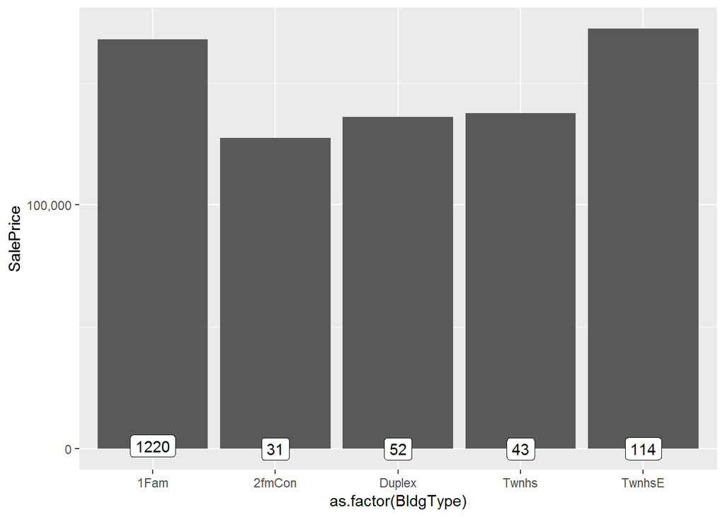

```r
ggplot(all[!is.na(all$SalePrice), ], mapping = aes(x = as.factor(BldgType), y = SalePrice)) +
        geom_bar(stat = 'summary', fun.y = "median") +
        scale_y_continuous(breaks = seq(0, 800000, by = 100000), labels = comma) +
        geom_label(stat = "count", mapping = aes(label = ..count.., y = ..count..))
```

从上面可以看出BldgType不是有序变量，所以只需将其转换为因子类型：

```r
#No ordinality, so converting into factors
all$BldgType <- as.factor(all$BldgType)
table(all$BldgType)
```

```
##
##   1Fam 2fmCon Duplex  Twnhs TwnhsE
##   2425     62    109     96    227
```

```r
sum(table(all$BldgType))
```

```
## [1] 2919
```

**(2) HouseStyle: Style of dwelling**

```
   1Story   One story
   1.5Fin   One and one-half story: 2nd level finished
   1.5Unf   One and one-half story: 2nd level unfinished
   2Story   Two story
   2.5Fin   Two and one-half story: 2nd level finished
   2.5Unf   Two and one-half story: 2nd level unfinished
   SFoyer   Split Foyer
   SLvl Split Level
```

HouseStyle不是有序变量，所以只需将其转换为因子类型：

```r
all$HouseStyle <- as.factor(all$HouseStyle)
table(all$HouseStyle)
```

```
##
## 1.5Fin 1.5Unf 1Story 2.5Fin 2.5Unf 2Story SFoyer   SLvl
##    314     19   1471      8     24    872     83    128
```

```r
sum(table(all$HouseStyle))
```

```
## [1] 2919
```

**Please return to the 5.3 Tabs menu to select other (groups of) variables**

### 5.3.6 Neighborhood and Conditions

**(1) Neighborhood: Physical locations within Ames city limits**

Note: as the number of levels is really high, I will look into binning later on.

```
   Blmngtn  Bloomington Heights
   Blueste  Bluestem
   BrDale   Briardale
   BrkSide  Brookside
   ClearCr  Clear Creek
   CollgCr  College Creek
   Crawfor  Crawford
   Edwards  Edwards
   Gilbert  Gilbert
   IDOTRR   Iowa DOT and Rail Road
   MeadowV  Meadow Village
   Mitchel  Mitchell
   Names    North Ames
   NoRidge  Northridge
   NPkVill  Northpark Villa
   NridgHt  Northridge Heights
   NWAmes   Northwest Ames
   OldTown  Old Town
   SWISU    South & West of Iowa State University
   Sawyer   Sawyer
   SawyerW  Sawyer West
   Somerst  Somerset
   StoneBr  Stone Brook
   Timber   Timberland
   Veenker  Veenker
```

Neighborhood不是有序变量，所以只需将其转换为因子类型：

```r
all$Neighborhood = as.factor(all$Neighborhood)
table(all$Neighborhood)
```

```
##
## Blmngtn Blueste  BrDale BrkSide ClearCr CollgCr Crawfor Edwards Gilbert
##      28      10      30     108      44     267     103     194     165
##  IDOTRR MeadowV Mitchel   NAmes NoRidge NPkVill NridgHt  NWAmes OldTown
##      93      37     114     443      71      23     166     131     239
##  Sawyer SawyerW Somerst StoneBr   SWISU  Timber Veenker
##     151     125     182      51      48      72      24
```

```r
sum(table(all$Neighborhood))
```

```
## [1] 2919
```

**(2) Condition1: Proximity to various conditions**

```
   Artery   Adjacent to arterial street
   Feedr    Adjacent to feeder street
   Norm Normal
   RRNn Within 200' of North-South Railroad
   RRAn Adjacent to North-South Railroad
   PosN Near positive off-site feature--park, greenbelt, etc.
   PosA Adjacent to postive off-site feature
   RRNe Within 200' of East-West Railroad
   RRAe Adjacent to East-West Railroad
```

Condition1不是有序变量，所以只需将其转换为因子类型：

```r
all$Condition1 = as.factor(all$Condition1)
table(all$Condition1)
```

```
##
## Artery  Feedr   Norm   PosA   PosN   RRAe   RRAn   RRNe   RRNn
##     92    164   2511     20     39     28     50      6      9
```

```r
sum(table(all$Condition1))
```

```
## [1] 2919
```

**(3) Condition2: Proximity to various conditions (if more than one is present)**

```
   Artery   Adjacent to arterial street
   Feedr    Adjacent to feeder street
   Norm Normal
   RRNn Within 200' of North-South Railroad
   RRAn Adjacent to North-South Railroad
   PosN Near positive off-site feature--park, greenbelt, etc.
   PosA Adjacent to postive off-site feature
   RRNe Within 200' of East-West Railroad
   RRAe Adjacent to East-West Railroad
```

Condition2不是有序变量，所以只需将其转换为因子类型：

```r
all$Condition2 <- as.factor(all$Condition2)
table(all$Condition2)
```

```
##
## Artery  Feedr   Norm   PosA   PosN   RRAe   RRAn   RRNn
##      5     13   2889      4      4      1      1      2
```

```r
sum(table(all$Condition2))
```

```
## [1] 2919
```

**Please return to the 5.3 Tabs menu to select other (groups of) variables**

### 5.3.7 Pavement of Street & Driveway

**(1) Street: Type of road access to property**

```
   Grvl Gravel
   Pave Paved
```

Street是有序变量，将其重编码为有序类别型变量：

```r
all$Street = as.integer(revalue(all$Street, c('Grvl' = 0, 'Pave' = 1)))
table(all$Street)
```

```
##
##    0    1
##   12 2907
```

```r
sum(table(all$Street))
```

```
## [1] 2919
```

**(2) PavedDrive: Paved driveway**

```
   Y    Paved
   P    Partial Pavement
   N    Dirt/Gravel
```

PavedDrive是有序变量，将其重编码为有序类别型变量：

```r
all$PavedDrive = as.integer(revalue(all$PavedDrive, c('N' = 0, 'P' = 1, 'Y' = 2)))
table(all$PavedDrive)
```

```
##
##    0    1    2
##  216   62 2641
```

```r
sum(table(all$PavedDrive))
```

```
## [1] 2919
```

**Please return to the 5.3 Tabs menu to select other (groups of) variables**

## 5.4 将一些数值型变量转换为因子类型

### 5.4.1 Year和Month Sold

```r
all$MoSold = as.factor(all$MoSold)
```

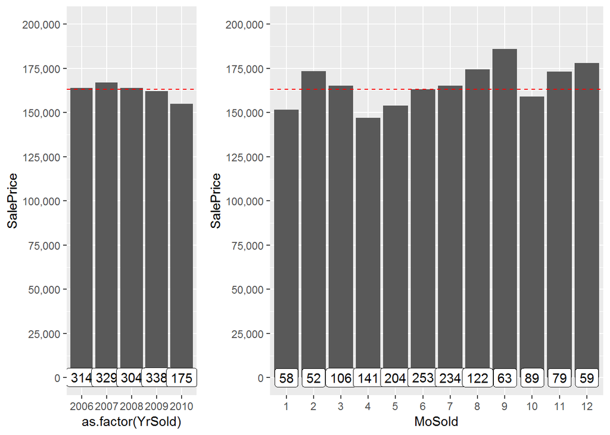

```r
ys = ggplot(data = all[!is.na(all$SalePrice), ], mapping = aes(x = as.factor(YrSold), y = SalePrice)) +
    geom_bar(stat = "summary", fun.y = "median") +
    scale_y_continuous(breaks = seq(0, 800000, by = 25000), labels = comma) +
    geom_label(stat = "count", mapping = aes(label = ..count.., y = ..count..)) +
    coord_cartesian(ylim = c(0, 200000)) +
    geom_hline(yintercept = median(all$SalePrice, na.rm = TRUE), linetype = "dashed", col = "red")
ms = ggplot(data = all[!is.na(all$SalePrice), ], mapping = aes(x = MoSold, y = SalePrice)) +
    geom_bar(stat = "summary", fun.y = "median") +
    scale_y_continuous(breaks = seq(0, 800000, by = 25000), labels = comma) +
    geom_label(stat = "count", mapping = aes(label = ..count.., y = ..count..)) +
    coord_cartesian(ylim = c(0, 200000)) +
    geom_hline(yintercept = median(all$SalePrice, na.rm = TRUE), linetype = "dashed", color = "red")
grid.arrange(ys, ms, widths = c(1, 2))
```

### 5.4.2 MSSubClass

MSSubClass确定销售涉及的住宅类型，应该是一个类别型变量：

```r
str(all$MSSubClass)
```

```
##  int [1:2919] 60 20 60 70 60 50 20 60 50 190 ...
```

```r
all$MSSubClass = as.factor(all$MSSubClass)
table(all$MSSubClass)
```

```
##
##   20   30   40   45   50   60   70   75   80   85   90  120  150  160  180
## 1079  139    6   18  287  575  128   23  118   48  109  182    1  128   17
##  190
##   61
```

```r
all$MSSubClass = revalue(all$MSSubClass, c('20' = '1 story 1946+',
                                           '30' = '1 story 1945-',
                                           '40' = '1 story unf attic',
                                           '45' = '1,5 story unf',
                                           '50' = '1,5 story fin',
                                           '60' = '2 story 1946+',
                                           '70' = '2 story 1945-',
                                           '75' = '2,5 story all ages',
                                           '80' = 'split/multi level',
                                           '85' = 'split foyer',
                                           '90' = 'duplex all style/age',
                                           '120' = '1 story PUD 1946+',
                                           '150' = '1,5 story PUD all',
                                           '160' = '2 story PUD 1946+',
                                           '180' = 'PUD multilevel',
                                           '190' = '2 family conversion'))
table(all$MSSubClass)
```

```
##
##        1 story 1946+        1 story 1945-    1 story unf attic
##                 1079                  139                    6
##        1,5 story unf        1,5 story fin        2 story 1946+
##                   18                  287                  575
##        2 story 1945-   2,5 story all ages    split/multi level
##                  128                   23                  118
##          split foyer duplex all style/age    1 story PUD 1946+
##                   48                  109                  182
##    1,5 story PUD all    2 story PUD 1946+       PUD multilevel
##                    1                  128                   17
##  2 family conversion
##                   61
```

# 6 重要变量的可视化

## 6.1 数值型变量的相关性可视化

```r
numericVars = which(sapply(all, is.numeric))
numericVars
```

```
##   LotFrontage       LotArea        Street      LotShape     LandSlope
##             3             4             5             7            10
##   OverallQual   OverallCond     YearBuilt  YearRemodAdd    MasVnrType
##            16            17            18            19            24
##    MasVnrArea     ExterQual     ExterCond      BsmtQual      BsmtCond
##            25            26            27            29            30
##  BsmtExposure  BsmtFinType1    BsmtFinSF1  BsmtFinType2    BsmtFinSF2
##            31            32            33            34            35
##     BsmtUnfSF   TotalBsmtSF     HeatingQC    CentralAir      1stFlrSF
##            36            37            39            40            42
##      2ndFlrSF  LowQualFinSF     GrLivArea  BsmtFullBath  BsmtHalfBath
##            43            44            45            46            47
##      FullBath      HalfBath  BedroomAbvGr  KitchenAbvGr   KitchenQual
##            48            49            50            51            52
##  TotRmsAbvGrd    Functional    Fireplaces   FireplaceQu   GarageYrBlt
##            53            54            55            56            58
##  GarageFinish    GarageCars    GarageArea    GarageQual    GarageCond
##            59            60            61            62            63
##    PavedDrive    WoodDeckSF   OpenPorchSF EnclosedPorch     3SsnPorch
##            64            65            66            67            68
##   ScreenPorch      PoolArea        PoolQC       MiscVal        YrSold
##            69            70            71            74            76
##     SalePrice
##            79
```

```r
factorVars = which(sapply(all, is.factor))
factorVars
```

```
##    MSSubClass      MSZoning         Alley   LandContour     LotConfig
##             1             2             6             8             9
##  Neighborhood    Condition1    Condition2      BldgType    HouseStyle
##            11            12            13            14            15
##     RoofStyle      RoofMatl   Exterior1st   Exterior2nd    Foundation
##            20            21            22            23            28
##       Heating    Electrical    GarageType         Fence   MiscFeature
##            38            41            57            72            73
##        MoSold      SaleType SaleCondition
##            75            77            78
```

```r
cat('有', length(numericVars), '个数值型变量, 有', length(factorVars), '个类别型变量.')
```

```
## 有 56 个数值型变量, 有 23 个类别型变量.
```

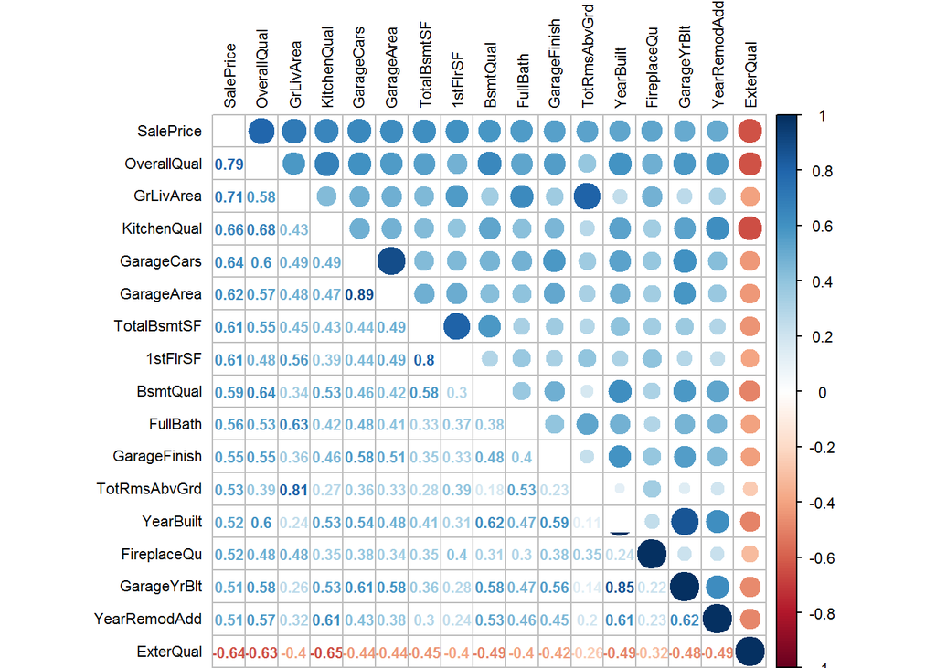

```r
all_numVar = all[, numericVars]
cor_numVar = cor(all_numVar, use = 'pairwise.complete.obs')
cor_sorted = as.matrix(sort(cor_numVar[, 'SalePrice'], decreasing = TRUE))
CorHigh = names(which(apply(cor_sorted, 1, function(x) abs(x) > 0.5)))
cor_numVar = cor_numVar[CorHigh, CorHigh]
corrplot.mixed(cor_numVar, tl.col = "black", tl.pos = "lt", tl.cex = 0.7, cl.cex = 0.7, number.cex = 0.7)
```

## 6.2 利用一个快速的随机森林模型分析变量的重要性

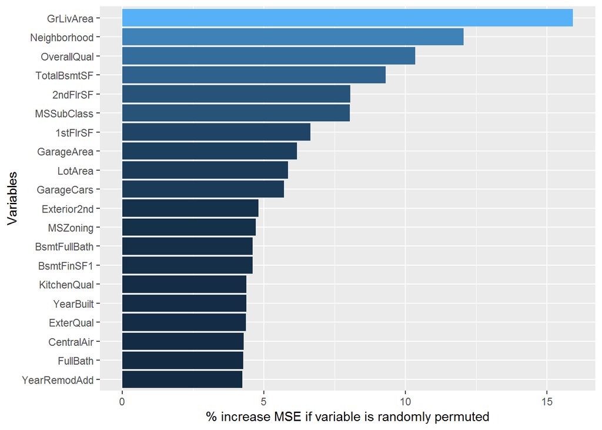

```r
set.seed(2018)
quick_RF = randomForest(x = all[1:1460, -79], y = all$SalePrice[1:1460], ntree = 100, importance = TRUE)
imp_RF = importance(quick_RF)
imp_DF = data.frame(Variables = row.names(imp_RF), MSE = imp_RF[, 1])
imp_DF = imp_DF[order(imp_DF$MSE, decreasing = TRUE), ]

ggplot(data = imp_DF[1:20, ], mapping = aes(x = reorder(Variables, MSE), y = MSE, fill = MSE)) +
    geom_bar(stat = 'identity') +
    labs(x = "Variables", y = "% increase MSE if variable is randomly permuted") +
    coord_flip() +
    theme(legend.position = "none")
```

## 6.3 GrLivArea变量和与其相关的面积(平方英尺)变量分布可视化

- GrLivArea：地面以上生活面积
- TotRmsAbvGrd：地面以上房间数
- X1stFlrSF: 一层居住面积
- X2ndFlrSF：二层居住面积
- TotalBsmtSF：地下室面积
- LotArea：Square feet lot
- LotFrontage：Linear feet lot frontage
- LowQualFinSF：一层和二层的低质量面积

```r
all %>%
    select(GrLivArea, TotRmsAbvGrd, "1stFlrSF", "2ndFlrSF", TotalBsmtSF, LotArea, LotFrontage, LowQualFinSF) %>%
    head()
```

```
## # A tibble: 6 x 8
##   GrLivArea TotRmsAbvGrd `1stFlrSF` `2ndFlrSF` TotalBsmtSF LotArea
##       <int>        <int>      <int>      <int>       <dbl>   <int>
## 1      1710            8        856        854        856.    8450
## 2      1262            6       1262          0       1262.    9600
## 3      1786            6        920        866        920.   11250
## 4      1717            7        961        756        756.    9550
## 5      2198            9       1145       1053       1145.   14260
## 6      1362            5        796        566        796.   14115
## # ... with 2 more variables: LotFrontage <dbl>, LowQualFinSF <int>
```

[figure not shown]

```r
s1 = ggplot(data = all, mapping = aes(x = GrLivArea)) +
    geom_density() +
    labs(x = "Square feet living area")
s2 = ggplot(data = all, mapping = aes(x = as.factor(TotRmsAbvGrd))) +
    geom_histogram(stat = "count") +
    labs(x = "Rooms above Ground")
s22 = ggplot(data = all, mapping = aes(x = as.factor(TotRmsAbvGrd))) +
    geom_bar(stat = "count") +
    labs(x = "Rooms above Ground")
s3 = ggplot(data = all, mapping = aes(x = "1stFlrSF")) +
    geom_density() +
    labs(x = "Square feet first floor")
s4 = ggplot(data = all, mapping = aes(x = "2ndFlrSF")) +
    geom_density() +
    labs(x = "Square feet second floor")
s5 = ggplot(data = all, mapping = aes(x = TotalBsmtSF)) +
    geom_density() +
    labs(x = "Square feet basement")
s6 = ggplot(data = all[all$LotArea < 100000, ], mapping = aes(x = LotArea)) +
    geom_density() +
    labs(x = "Square feet lot")
s7 = ggplot(data = all, mapping = aes(x = LotFrontage)) +
    geom_density() +
    labs(x = "Linear feet lot frontage")
s8 = ggplot(data = all, mapping = aes(x = LowQualFinSF)) +
    geom_histogram() +
    labs(x = "Low quality square feet 1st & 2nd")
layout = matrix(c(1, 2, 5, 3, 4, 8, 6, 7), 4, 2, byrow = TRUE)
multiplot(s1, s2, s3, s4, s5, s6, s7, s8, layout = layout)
```

```r
cor(all$GrLivArea, (all$`1stFlrSF` + all$`2ndFlrSF` + all$LowQualFinSF))
```

```
## [1] 1
```

```r
all %>%
    filter(LowQualFinSF > 0) %>%
    select(GrLivArea, `1stFlrSF`, `2ndFlrSF`, LowQualFinSF)
```

```
## # A tibble: 40 x 4
##    GrLivArea `1stFlrSF` `2ndFlrSF` LowQualFinSF
##        <int>      <int>      <int>        <int>
##  1      1176        816          0          360
##  2      1526       1013          0          513
##  3       754        520          0          234
##  4      1382        854          0          528
##  5      3608       1518       1518          572
##  6      1656        808        704          144
##  7      3112       1360       1360          392
##  8      2229        929        929          371
##  9      1316        926          0          390
## 10      2192       1052        720          420
## # ... with 30 more rows
```

可以发下GrLivArea是1stFlrSF, 2ndFlrSF, LowQualFinSF这三个变量的和。

## 6.4 最重要的类别型变量Neighborhood

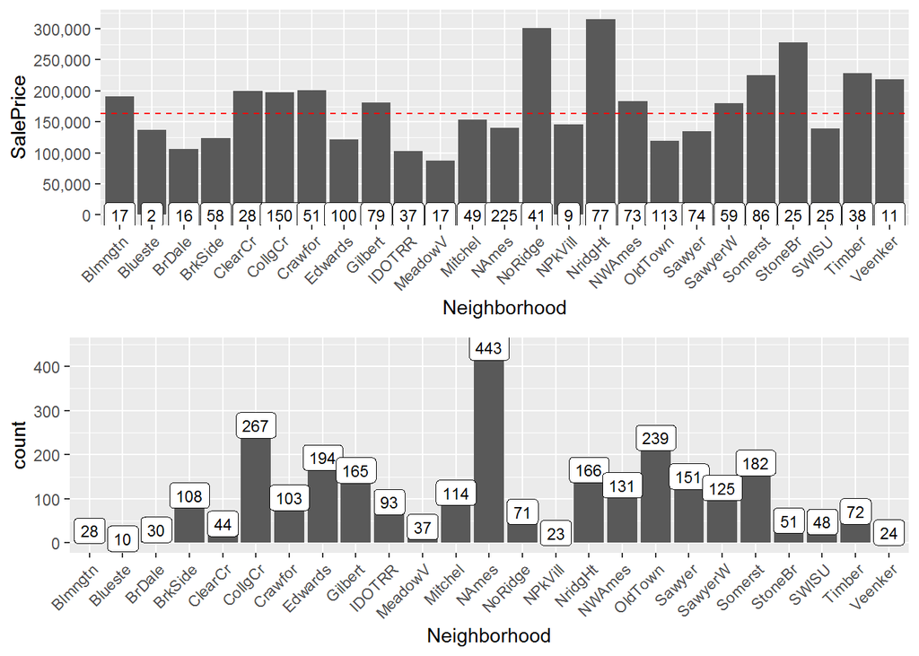

```r
n1 = ggplot(data = all[!is.na(all$SalePrice), ], mapping = aes(x = Neighborhood, y = SalePrice)) +
    geom_bar(stat = "summary", fun.y = "median") +
    theme(axis.text.x = element_text(angle = 45, hjust = 1)) +
    scale_y_continuous(breaks = seq(0, 800000, by = 50000), labels = comma) +
    geom_label(stat = "count", mapping = aes(label = ..count.., y = ..count..), size = 3) +
    geom_hline(yintercept = median(all$SalePrice, na.rm = TRUE), linetype = "dashed", color = "red")

n2 = ggplot(data = all, mapping = aes(x = Neighborhood)) +
    geom_histogram(stat = "count") +
    geom_label(stat = "count", mapping = aes(label = ..count.., y = ..count..), size = 3) +
    theme(axis.text.x = element_text(angle = 45, hjust = 1))
grid.arrange(n1, n2)
```

## 6.5 房子的总体质量，以及和质量相关的变量

和房子质量相关的变量：

- OverallQual
- ExterQual
- BsmtQual
- KitchenQual
- GarageQual
- FireplaceQu
- PoolQC

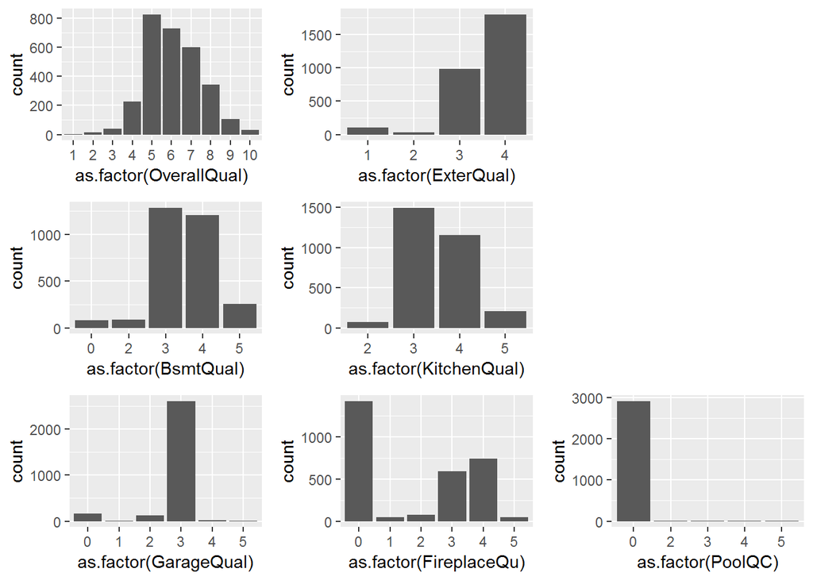

```r
q1 = ggplot(data = all, aes(x = as.factor(OverallQual))) +
        geom_histogram(stat = 'count')
q2 = ggplot(data = all, aes(x = as.factor(ExterQual))) +
        geom_histogram(stat = 'count')
q3 = ggplot(data = all, aes(x = as.factor(BsmtQual))) +
        geom_histogram(stat = 'count')
q4 = ggplot(data = all, aes(x = as.factor(KitchenQual))) +
        geom_histogram(stat = 'count')
q5 = ggplot(data = all, aes(x = as.factor(GarageQual))) +
        geom_histogram(stat = 'count')
q6 = ggplot(data = all, aes(x = as.factor(FireplaceQu))) +
        geom_histogram(stat = 'count')
q7 = ggplot(data = all, aes(x = as.factor(PoolQC))) +
        geom_histogram(stat = 'count')

layout = matrix(c(1, 2, 8, 3, 4, 8, 5, 6, 7), 3, 3,byrow = TRUE)
multiplot(q1, q2, q3, q4, q5, q6, q7, layout = layout)
```

## 6.6 MSSubClass

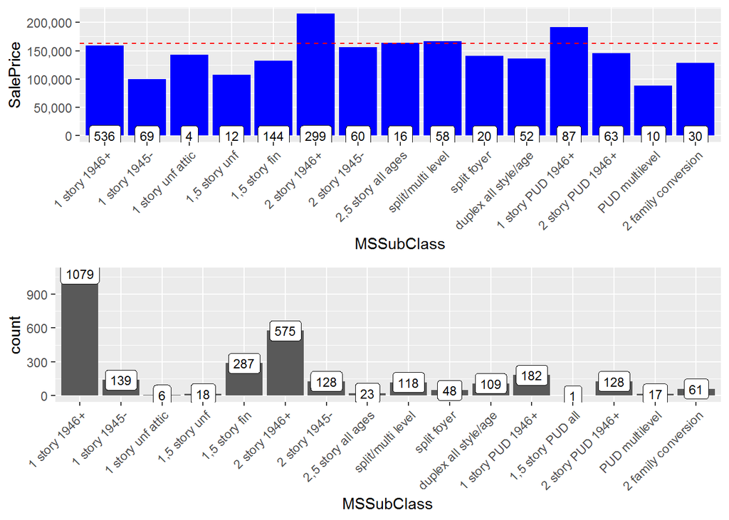

```r
ms1 <- ggplot(all[!is.na(all$SalePrice),], aes(x=MSSubClass, y=SalePrice)) +
        geom_bar(stat='summary', fun.y = "median", fill='blue') +
        theme(axis.text.x = element_text(angle = 45, hjust = 1)) +
        scale_y_continuous(breaks= seq(0, 800000, by=50000), labels = comma) +
        geom_label(stat = "count", aes(label = ..count.., y = ..count..), size=3) +
        geom_hline(yintercept=163000, linetype="dashed", color = "red") #dashed line is median SalePrice
ms2 <- ggplot(data=all, aes(x=MSSubClass)) +
        geom_histogram(stat='count')+
        geom_label(stat = "count", aes(label = ..count.., y = ..count..), size=3) +
        theme(axis.text.x = element_text(angle = 45, hjust = 1))
grid.arrange(ms1, ms2)
```

## 6.7 车库变量

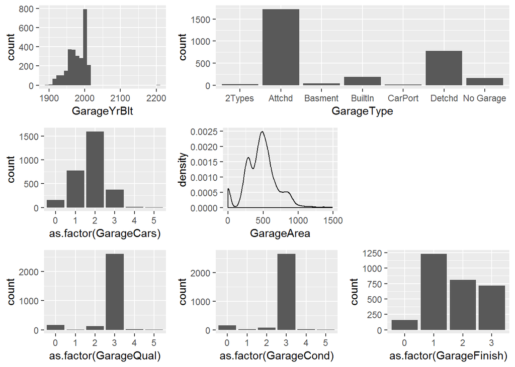

```r
g1 <- ggplot(data=all[all$GarageCars !=0,], aes(x=GarageYrBlt)) +
        geom_histogram()
g2 <- ggplot(data=all, aes(x=as.factor(GarageCars))) +
        geom_histogram(stat='count')
g3 <- ggplot(data= all, aes(x=GarageArea)) +
        geom_density()
g4 <- ggplot(data=all, aes(x=as.factor(GarageCond))) +
        geom_histogram(stat='count')
g5 <- ggplot(data=all, aes(x=GarageType)) +
        geom_histogram(stat='count')
g6 <- ggplot(data=all, aes(x=as.factor(GarageQual))) +
        geom_histogram(stat='count')
g7 <- ggplot(data=all, aes(x=as.factor(GarageFinish))) +
        geom_histogram(stat='count')

layout <- matrix(c(1,5,5,2,3,8,6,4,7),3,3,byrow=TRUE)
multiplot(g1, g2, g3, g4, g5, g6, g7, layout=layout)
```

## 6.8 地下室变量

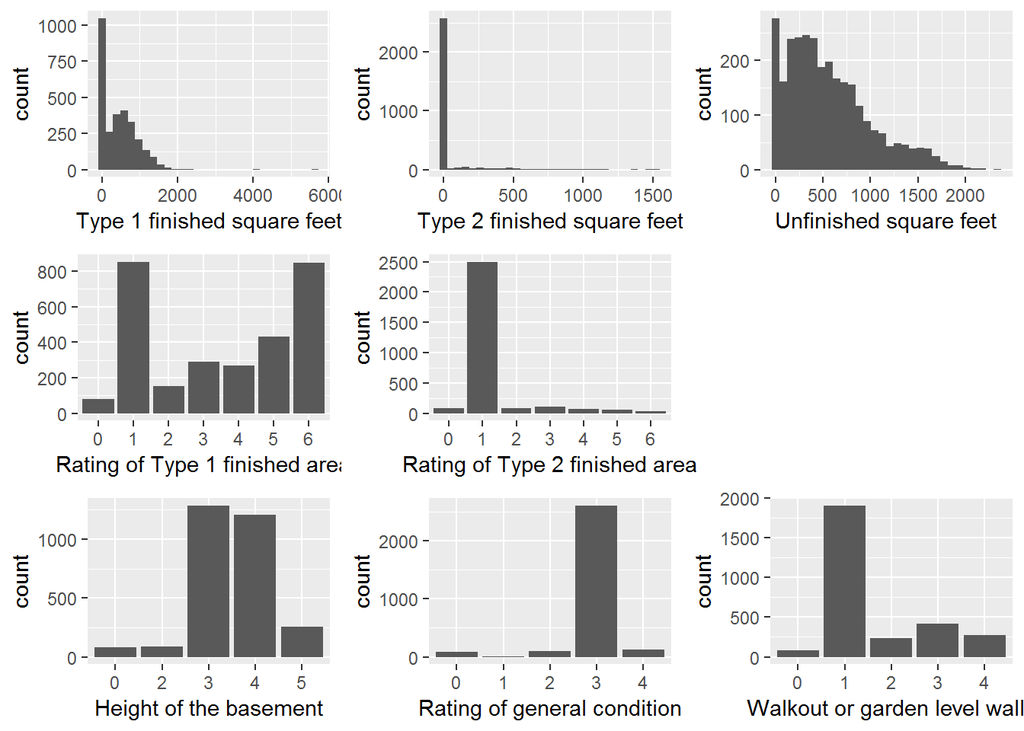

```r
b1 <- ggplot(data=all, aes(x=BsmtFinSF1)) +
        geom_histogram() + labs(x='Type 1 finished square feet')
b2 <- ggplot(data=all, aes(x=BsmtFinSF2)) +
        geom_histogram()+ labs(x='Type 2 finished square feet')
b3 <- ggplot(data=all, aes(x=BsmtUnfSF)) +
        geom_histogram()+ labs(x='Unfinished square feet')
b4 <- ggplot(data=all, aes(x=as.factor(BsmtFinType1))) +
        geom_histogram(stat='count')+ labs(x='Rating of Type 1 finished area')
b5 <- ggplot(data=all, aes(x=as.factor(BsmtFinType2))) +
        geom_histogram(stat='count')+ labs(x='Rating of Type 2 finished area')
b6 <- ggplot(data=all, aes(x=as.factor(BsmtQual))) +
        geom_histogram(stat='count')+ labs(x='Height of the basement')
b7 <- ggplot(data=all, aes(x=as.factor(BsmtCond))) +
        geom_histogram(stat='count')+ labs(x='Rating of general condition')
b8 <- ggplot(data=all, aes(x=as.factor(BsmtExposure))) +
        geom_histogram(stat='count')+ labs(x='Walkout or garden level walls')

layout <- matrix(c(1,2,3,4,5,9,6,7,8),3,3,byrow=TRUE)
multiplot(b1, b2, b3, b4, b5, b6, b7, b8, layout=layout)
```

# 7 特征工程

## 7.1 浴室总数量变量

共有4个浴室变量

```r
bathCols = all %>%
    select(ends_with("Bath")) %>%
    head()
bathCols
```

```
## # A tibble: 6 x 4
##   BsmtFullBath BsmtHalfBath FullBath HalfBath
##          <dbl>        <dbl>    <int>    <int>
## 1           1.           0.        2        1
## 2           0.           1.        2        0
## 3           1.           0.        2        1
## 4           1.           0.        1        0
## 5           1.           0.        2        1
## 6           1.           0.        1        1
```

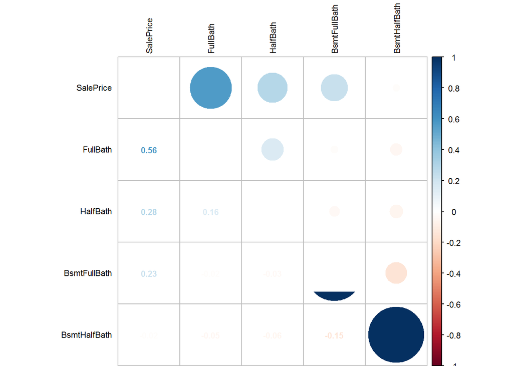

```r
cor_numVar = cor(all[, c(names(bathCols), "SalePrice")], use = 'pairwise.complete.obs')
cor_sorted = as.matrix(sort(cor_numVar[, 'SalePrice'], decreasing = TRUE))
CorHigh = names(which(apply(cor_sorted, 1, function(x) abs(x) > 0)))
cor_numVar = cor_numVar[CorHigh, CorHigh]
corrplot.mixed(cor_numVar, tl.col = "black", tl.pos = "lt", tl.cex = 0.7, cl.cex = 0.7, number.cex = 0.7)
```

从上面的分析看出，单个浴室变量与SalePrice的相关性最大为0.56，其余变量与SalePrice的相关性都很小，所以创建一个浴室总数量变量，来总体描述浴室的数量，并检测它与SalePrice的相关性，可以看到新建的浴室总数量明显可以很好地描述浴室对于SalePrice的影响：

```r
all$TotBathrooms = all$FullBath + (all$HalfBath * 0.5) + all$BsmtFullBath + (all$BsmtHalfBath * 0.5)
cor(all[, c("TotBathrooms", "SalePrice")], use = 'pairwise.complete.obs')
```

```
##              TotBathrooms SalePrice
## TotBathrooms    1.0000000 0.6317311
## SalePrice       0.6317311 1.0000000
```

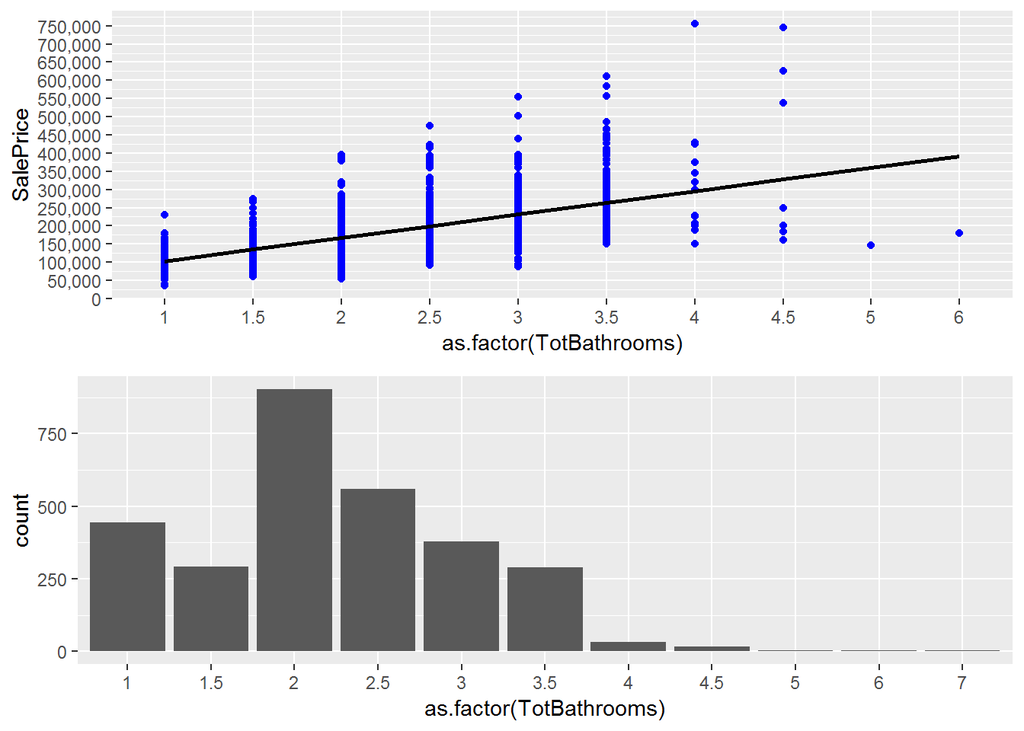

```r
tb1 = ggplot(data = all[!is.na(all$SalePrice), ], mapping = aes(x = as.factor(TotBathrooms), y = SalePrice)) +
    geom_point(col = "blue") +
    geom_smooth(method = "lm", se = FALSE, color = "black", mapping = aes(group = 1)) +
    scale_y_continuous(breaks = seq(0, 800000, by = 50000), label = comma)
tb2 = ggplot(data = all, mapping = aes(x = as.factor(TotBathrooms))) +
    geom_histogram(stat = "count")
grid.arrange(tb1, tb2)
```

## 7.2 新建HouseAge(房子年龄)变量，IsNew(是否为新房子)变量

```r
all %>%
    select(starts_with("Year"), YrSold) %>%
    head()
```

```
## # A tibble: 6 x 3
##   YearBuilt YearRemodAdd YrSold
##       <int>        <int>  <int>
## 1      2003         2003   2008
## 2      1976         1976   2007
## 3      2001         2002   2008
## 4      1915         1970   2006
## 5      2000         2000   2008
## 6      1993         1995   2009
```

有三个变量和房子的年龄有关，YearBlt, YearRemodAdd, YearSold：

- YearBuilt:房子建造的年份
- YearRemodAdd：房子翻新的年份
- YrSold：房子出售的年份

- 房子是否进行过翻新
- 房子是否是新房子(如果房子的建造年份与房子的出售年份相同则认为是新房子)
- 房子的年龄(房子的出售年份-房子的翻新年份)

```r
all$Remod = ifelse(all$YearBuilt == all$YearRemodAdd, 0, 1)
all$Age = as.numeric(all$YrSold) - all$YearRemodAdd
all$IsNew = ifelse(all$YrSold == all$YearBuilt, 1, 0)
```

- Age

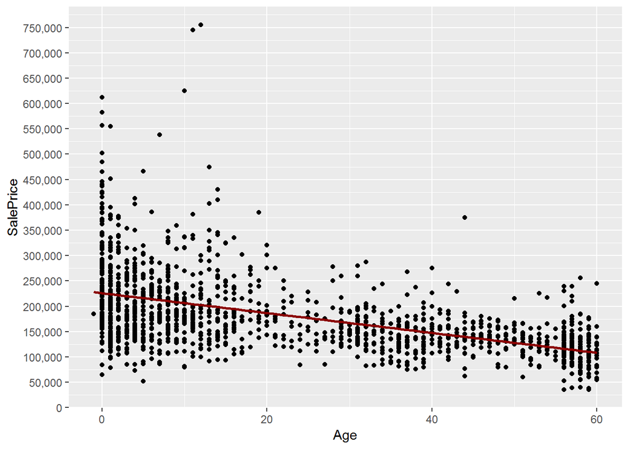

```r
ggplot(data = all[!is.na(all$SalePrice), ], mapping = aes(x = Age, y = SalePrice)) +
    geom_point() +
    geom_smooth(method = "lm", se = FALSE, color = "darkred", mapping = aes(group = 1)) +
    scale_y_continuous(breaks = seq(0, 800000, by = 50000), labels = comma)
```

```r
cor(all$SalePrice[!is.na(all$SalePrice)], all$Age[!is.na(all$SalePrice)])
```

```
## [1] -0.5090787
```

从上面的分析可以看出，Age变量和SalePrice有负的相关关系，但是相关性不是特别强。

- Remod

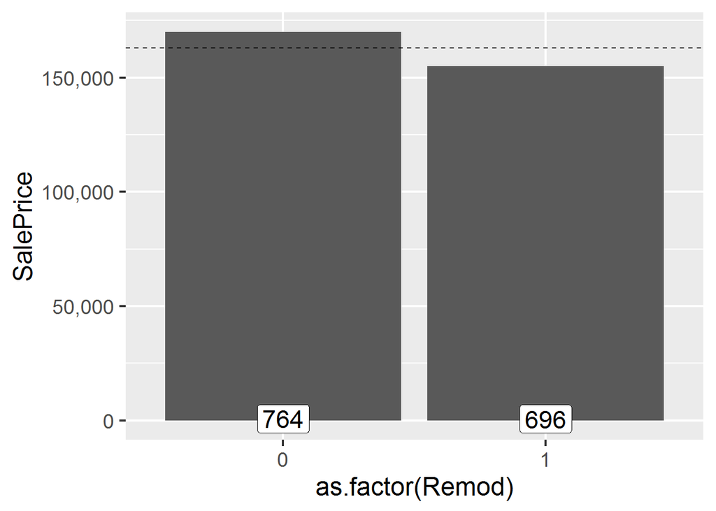

```r
ggplot(data = all[!is.na(all$SalePrice), ], mapping = aes(x = as.factor(Remod), y = SalePrice)) +
    geom_bar(stat = "summary", fun.y = "median") +
    geom_label(stat = "count", aes(label = ..count.., y = ..count..), size = 6) +
    scale_y_continuous(breaks = seq(0, 800000, by = 50000), labels = comma) +
    theme_grey(base_size = 18) +
    geom_hline(yintercept = 163000, linetype = "dashed")
```

分析得出，进行过翻修的房子的价格相比于没有进行过翻修的房子价格要低。

- IsNew

```r
table(all$IsNew)
```

```
##
##    0    1
## 2803  116
```

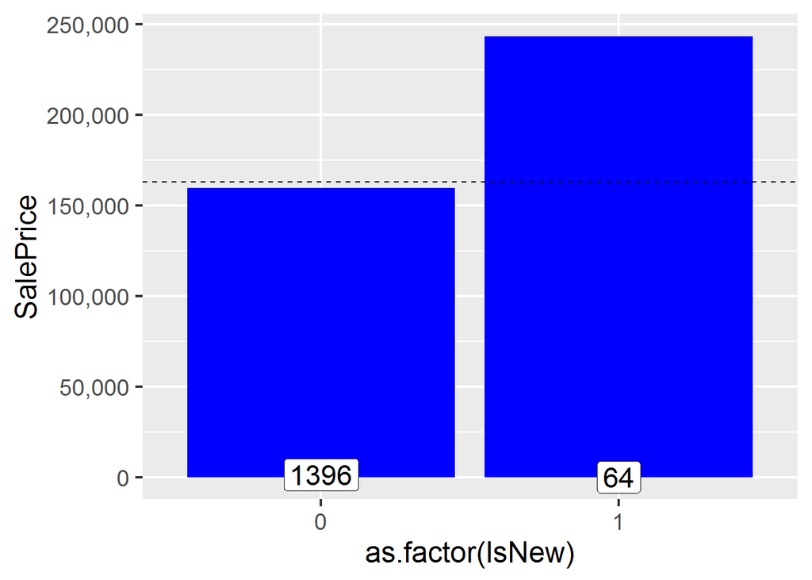

```r
ggplot(all[!is.na(all$SalePrice), ], mapping = aes(x = as.factor(IsNew), y = SalePrice)) +
        geom_bar(stat = 'summary', fun.y = "median", fill = 'blue') +
        geom_label(stat = "count", aes(label = ..count.., y = ..count..), size = 6) +
        scale_y_continuous(breaks = seq(0, 800000, by = 50000), labels = comma) +
        theme_grey(base_size = 18) +
        geom_hline(yintercept = 163000, linetype = "dashed")
```

从上面的分析可以看出，新房子要明显比老房子要贵。

## 7.3 对Neighborhood变量进行分箱

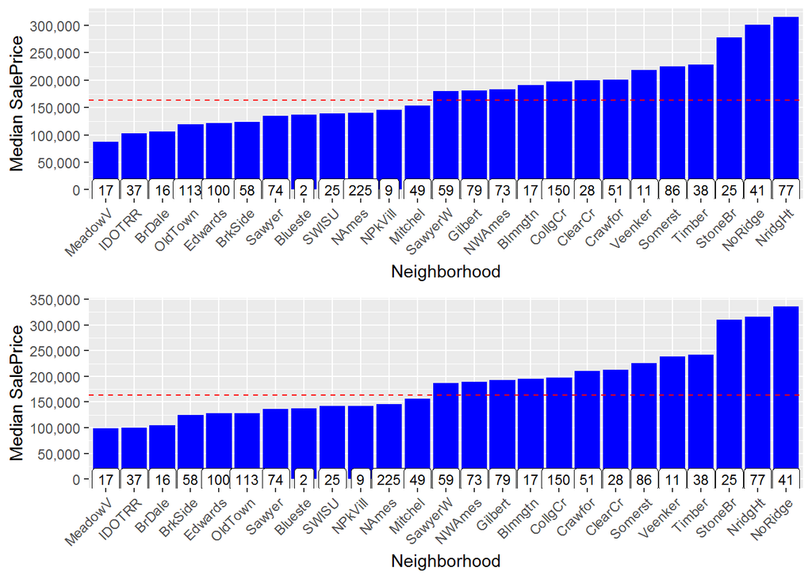

```r
nb1 = ggplot(data = all[!is.na(all$SalePrice), ],
             mapping = aes(x = reorder(Neighborhood, SalePrice, FUN = median), y = SalePrice)) +
    geom_bar(stat = "summary", fun.y = "median", fill = "blue") +
    labs(x = "Neighborhood", y = "Median SalePrice") +
    theme(axis.text.x = element_text(angle = 45, hjust = 1)) +
    scale_y_continuous(breaks = seq(0, 800000, by = 50000), labels = comma) +
    geom_label(stat = "count", mapping = aes(label = ..count.., y = ..count..), size = 3) +
    geom_hline(yintercept = 163000, linetype = "dashed", color = "red")

nb2 = ggplot(data = all[!is.na(all$SalePrice), ],
             mapping = aes(x = reorder(Neighborhood, SalePrice, FUN = mean), y = SalePrice)) +
    geom_bar(stat = "summary", fun.y = "mean", fill = "blue") +
    labs(x = "Neighborhood", y = "Median SalePrice") +
    theme(axis.text.x = element_text(angle = 45, hjust = 1)) +
    scale_y_continuous(breaks = seq(0, 800000, by = 50000), labels = comma) +
    geom_label(stat = "count", mapping = aes(label = ..count.., y = ..count..), size = 3) +
    geom_hline(yintercept = 163000, linetype = "dashed", color = "red")


grid.arrange(nb1, nb2)
```

从上面的分析可以看出，有三种Neighborhood对应的房子价格明显高于其他的Neighborhood，也有三种Neighborhood对应的房子价格明显低于其他的Neighborhood，所以讲Neighborhood重新进行编码：

```r
all$NeighRich[all$Neighborhood %in% c("StoneBr", "NridgHt", "NoRidge")] = 2
all$NeighRich[!all$Neighborhood %in% c("MeadowV", "IDOTRR", "BrDale", "StoneBr", "NridgHt", "NoRidge")] = 1

all$NeighRich[all$Neighborhood %in% c("MeadowV", "IDOTRR", "BrDale")] = 0

table(all$NeighRich)
```

```
##
##    0    1    2
##  160 2471  288
```

## 7.4 新建总面积

对买房子的人来说非常看重房子的总面积，所以新建一个将地下和地上面积加总的面基变量：

```r
all$TotalSqFeet = all$GrLivArea + all$TotalBsmtSF
```

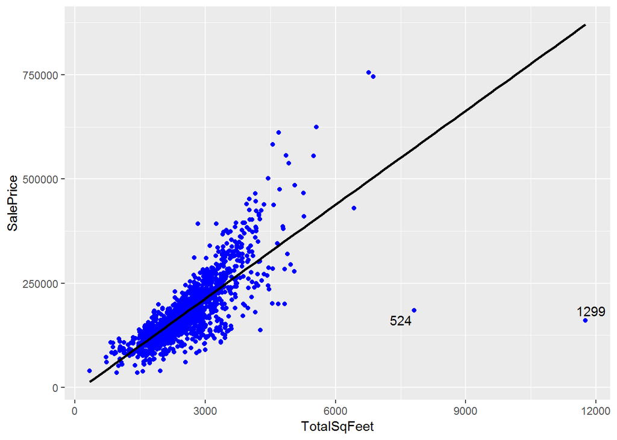

```r
ggplot(data = all[!is.na(all$SalePrice), ],
       mapping = aes(x = TotalSqFeet, y = SalePrice)) +
    geom_point(col = "blue") +
    geom_smooth(method = "lm", se = FALSE, colour = "black", mapping = aes(group = 1)) +
    geom_text_repel(mapping = aes(label = ifelse(all$GrLivArea[!is.na(all$SalePrice)] > 4500, rownames(all), '')))
```

```r
cor(all$SalePrice, all$TotalSqFeet, use = "pairwise.complete.obs")
```

```
## [1] 0.7789588
```

从上面的分析看出，新建的总面积变量和SalePrice有很强的相关关系，但是从两个变量的散点图中可以看出，有两个特别明显的异常值存在，下面给出去除掉这两个异常值后两个变量的相关关系：

```r
cor(all$SalePrice[-c(524, 1299)], all$TotalSqFeet[-c(524, 1299)], use = "pairwise.complete.obs")
```

```
## [1] 0.829042
```

## 7.5 合并阳台(门廊)变量

下面是与阳台有关的变量：

- WoodDeckSF: Wood deck area in square feet
- OpenPorchSF: Open porch area in square feet
- EnclosedPorch: Enclosed porch area in square feet
- 3SsnPorch: Three season porch area in square feet
- ScreenPorch: Screen porch area in square feet

阳台或者门廊是房子处于顶部遮蔽的地方，而这里的WoodDeckSF是没有遮蔽的场所，所以这里仅考虑其他四个变量：

```r
all$TotalProchSF = all$OpenPorchSF + all$EnclosedPorch + all$`3SsnPorch` + all$ScreenPorch
```

```r
cor(all$SalePrice, all$TotalProchSF, use = "pairwise.complete.obs")
```

```
## [1] 0.1957389
```

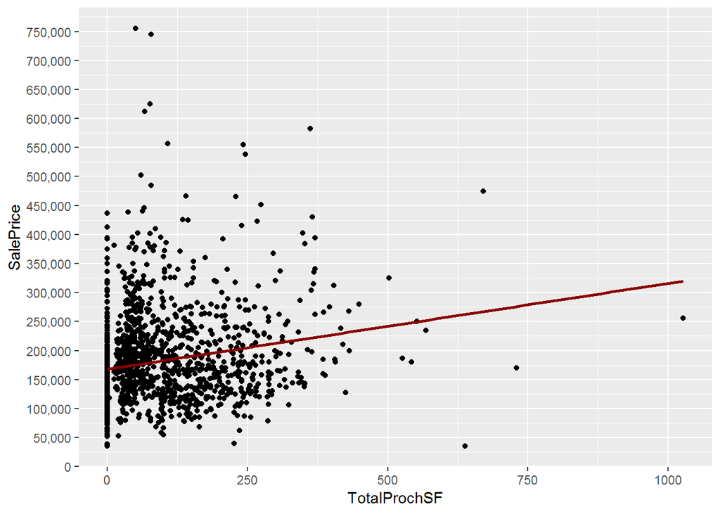

```r
ggplot(data = all[!is.na(all$SalePrice), ], mapping = aes(x = TotalProchSF, y = SalePrice)) +
    geom_point() +
    geom_smooth(method = "lm", se = FALSE, colour = "darkred", mapping = aes(group = 1)) +
    scale_y_continuous(breaks = seq(0, 800000, by = 50000), labels = comma)
```

# 8 将数据预处理为建模可用的数据类型和格式

## 8.1 删除相关性强的预测变量

```r
all_numVar = all[, numericVars]
cor_numVar = cor(all_numVar, use = 'pairwise.complete.obs')
cor_sorted = as.matrix(sort(abs(cor_numVar[, 'SalePrice']), decreasing = TRUE))
cor_sorted
```

```
##                      [,1]
## SalePrice     1.000000000
## OverallQual   0.790981601
## GrLivArea     0.708624478
## KitchenQual   0.659599721
## GarageCars    0.640409197
## ExterQual     0.636883694
## GarageArea    0.623431439
## TotalBsmtSF   0.613580552
## 1stFlrSF      0.605852185
## BsmtQual      0.585207199
## FullBath      0.560663763
## GarageFinish  0.549246756
## TotRmsAbvGrd  0.533723156
## YearBuilt     0.522897333
## FireplaceQu   0.520437606
## GarageYrBlt   0.508043287
## YearRemodAdd  0.507100967
## MasVnrArea    0.472614499
## Fireplaces    0.466928837
## HeatingQC     0.427648707
## MasVnrType    0.426702816
## BsmtFinSF1    0.386419806
## BsmtExposure  0.375044959
## LotFrontage   0.347805684
## WoodDeckSF    0.324413445
## 2ndFlrSF      0.319333803
## OpenPorchSF   0.315856227
## BsmtFinType1  0.304907873
## HalfBath      0.284107676
## GarageQual    0.273839074
## LotShape      0.267759314
## LotArea       0.263843354
## GarageCond    0.263190784
## CentralAir    0.251328164
## PavedDrive    0.231356952
## BsmtFullBath  0.227122233
## BsmtUnfSF     0.214479106
## BsmtCond      0.212607156
## BedroomAbvGr  0.168213154
## KitchenAbvGr  0.135907371
## EnclosedPorch 0.128577958
## PoolQC        0.111695838
## ScreenPorch   0.111446571
## Functional    0.107618893
## PoolArea      0.092403549
## OverallCond   0.077855894
## LandSlope     0.051152248
## 3SsnPorch     0.044583665
## Street        0.041035536
## YrSold        0.028922585
## LowQualFinSF  0.025606130
## MiscVal       0.021189580
## ExterCond     0.018899118
## BsmtHalfBath  0.016844154
## BsmtFinSF2    0.011378121
## BsmtFinType2  0.004329316
```

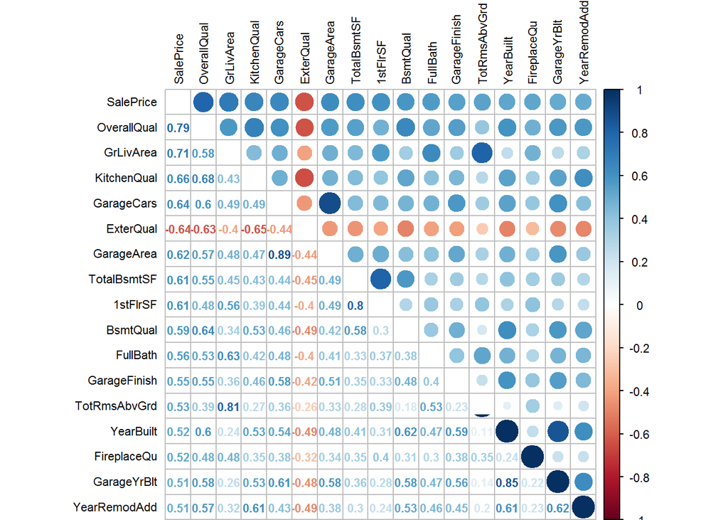

```r
CorHigh = names(which(apply(cor_sorted, 1, function(x) abs(x) > 0.5)))
cor_numVar = cor_numVar[CorHigh, CorHigh]
corrplot.mixed(cor_numVar, tl.col = "black", tl.pos = "lt", tl.cex = 0.7, cl.cex = 0.7, number.cex = 0.7)
```

首先，删除两个相关变量中与SalePrice相关性更弱的那一个变量：

```r
dim(all)
```

```
## [1] 2919   86
```

```r
dropVars = c("YearRemodAdd", "GarageYrBlt", "GarageArea", "GarageCond", "TotalBsmtSF", "TotalRmsAbvGrd", "BsmtFinSF1")
all = all[, !names(all) %in% dropVars]
dim(all)
```

```
## [1] 2919   80
```

## 8.2 删除异常值

删除两个房子面积很大而房子的价格很小的房子的观测值：

```r
all = all[- c(524, 1299), ]
```

## 8.3 对预测变量进行预处理

- 对数值型变量(非经过重编码的变量)进行标准化、中心化
- 对类别型变量重编码为哑变量(dummy variable)

```r
numericVarNames = numericVarNames[!(numericVarNames %in% c("MSSubClass", "MoSold", "YrSold", "SalePrice", "OverallQual", "OverallCond"))]
numericVarNames = append(numericVarNames, c("Age", "TotalPorchSF", "TotBathrooms", "TotalSqFeet"))
DFnumeric = all[, names(all) %in% numericVarNames]
DFfactors = all[, !names(all) %in% numericVarNames]
DFfactors = DFfactors[, names(DFfactors) != "SalePrice"]
cat("有", length(DFnumeric), "个数值型变量; 有", length(DFfactors), "个因子型变量.")
```

```
## 有 29 个数值型变量; 有 50 个因子型变量.
```

### 8.3.1 数值型变量的偏度和正态性

- **偏度**

偏度一般度量一个分布的对称性，对称分布的偏度为0，因此，一个正态分布的偏度为0。根据经验，一个分布如果是对称分布或接近对称分布，则它的偏度在[-1, 1]的范围内。所以，为了修正预测变量的偏度，将所有偏度的绝对值大于0.8的数值型变量取对数(实际上是log(x + 1)，防止变量观测值为0):

```r
ncol(DFnumeric)
```

```
## [1] 29
```

```r
for(i in 1:ncol(DFnumeric)) {
     if (abs(skew(DFnumeric[, i])) > 0.8) {
         DFnumeric[, i] = log(DFnumeric[, i] + 1)
     }
}
```

- **规范化**

```r
PreNum = preProcess(DFnumeric, method = c("center", "scale"))
print(PreNum)
```

```
## Created from 2915 samples and 29 variables
##
## Pre-processing:
##   - centered (29)
##   - ignored (0)
##   - scaled (29)
```

```r
DFnorm = predict(PreNum, DFnumeric)
dim(DFnorm)
```

```
## [1] 2917   29
```

### 8.3.2 将类别型变量转换为哑变量

```r
DFdummies = as.data.frame(model.matrix(~.-1, DFfactors))
dim(DFdummies)
```

```
## [1] 2917  199
```

### 8.3.3 删除在训练数据集或测试数据集中只有少量或没有观测值的水平

```r
ZerocolTest = which(colSums(DFdummies[(nrow(all[is.na(all$SalePrice), ]) + 1):nrow(all), ]) == 0)
colnames(DFdummies[ZerocolTest])
```

```
##  [1] "Condition2RRAe"     "Condition2RRAn"     "Condition2RRNn"
##  [4] "HouseStyle2.5Fin"   "RoofMatlMembran"    "RoofMatlMetal"
##  [7] "RoofMatlRoll"       "Exterior1stImStucc" "Exterior1stStone"
## [10] "Exterior2ndOther"   "HeatingOthW"        "ElectricalMix"
## [13] "MiscFeatureTenC"
```

```r
DFdummies = DFdummies[, -ZerocolTest]

ZerocolTrain = which(colSums(DFdummies[1:nrow(all[is.na(all$SalePrice), ]), ]) == 0)
colnames(DFdummies[ZerocolTrain])
```

```
## [1] "MSSubClass1,5 story PUD all"
```

```r
DFdummies = DFdummies[, -ZerocolTrain]

fewOnes = which(colSums(DFdummies[1:nrow(all[!is.na(all$SalePrice), ]), ]) < 10)
colnames(DFdummies[fewOnes])
```

```
##  [1] "MSSubClass1 story unf attic" "LotConfigFR3"
##  [3] "NeighborhoodBlueste"         "NeighborhoodNPkVill"
##  [5] "Condition1PosA"              "Condition1RRNe"
##  [7] "Condition1RRNn"              "Condition2Feedr"
##  [9] "Condition2PosA"              "Condition2PosN"
## [11] "RoofStyleMansard"            "RoofStyleShed"
## [13] "RoofMatlWdShake"             "RoofMatlWdShngl"
## [15] "Exterior1stAsphShn"          "Exterior1stBrkComm"
## [17] "Exterior1stCBlock"           "Exterior2ndAsphShn"
## [19] "Exterior2ndBrk Cmn"          "Exterior2ndCBlock"
## [21] "Exterior2ndStone"            "FoundationStone"
## [23] "FoundationWood"              "HeatingGrav"
## [25] "HeatingWall"                 "ElectricalFuseP"
## [27] "GarageTypeCarPort"           "MiscFeatureOthr"
## [29] "SaleTypeCon"                 "SaleTypeConLD"
## [31] "SaleTypeConLI"               "SaleTypeConLw"
## [33] "SaleTypeCWD"                 "SaleTypeOth"
## [35] "SaleConditionAdjLand"
```

```r
DFdummies <- DFdummies[,-fewOnes]
dim(DFdummies)
```

```
## [1] 2917  150
```

```r
combined <- cbind(DFnorm, DFdummies)
```

## 8.4 对响应变量SalePrice偏度进行处理

- SalePrice正态性检验

```r
skew(all$SalePrice)
```

```
## [1] 1.877427
```

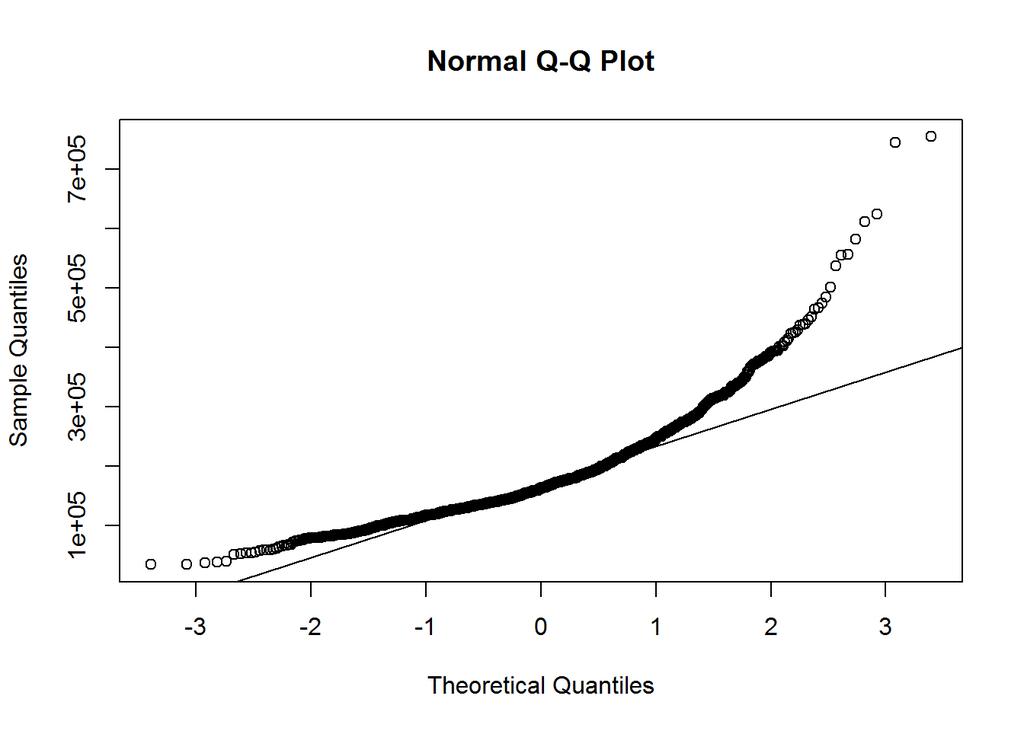

```r
qqnorm(all$SalePrice)
qqline(all$SalePrice)
```

- SalePrice正态性转换

```r
all$SalePrice = log(all$SalePrice + 1)
skew(all$SalePrice)
```

```
## [1] 0.1213297
```

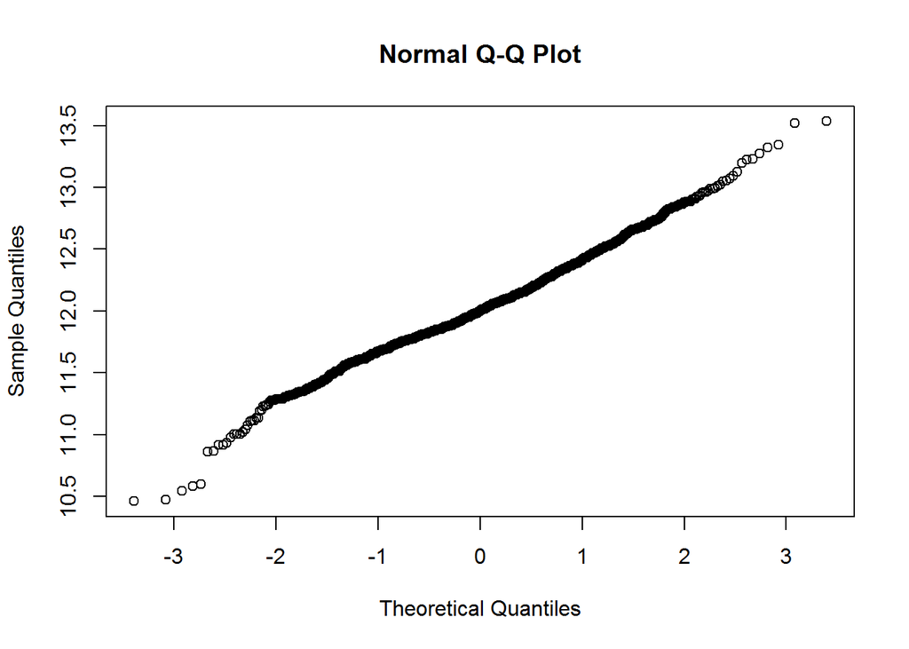

```r
qqnorm(all$SalePrice)
```

```r
# qqline(all$SalePrice)
```

## 8.5 将All分割为训练数据集和验证数据集

```r
train1 = combined[!is.na(all$SalePrice), ]
dim(train1)
```

```
## [1] 1458  179
```

```r
test1 = combined[is.na(all$SalePrice), ]
dim(test1)
```

```
## [1] 1459  179
```

# 9 利用Lasso和XGBoost算法建模

## 9.3 Lasso Regression

```r
set.seed(27042018)
my_control = trainControl(method = "cv", number = 5)
lassoGrid = expand.grid(alpha = 1,
                        lambda = seq(0.001, 0.1, by = 0.0005))
lasso_mod = train(x = train1, y = all$SalePrice[!is.na(all$SalePrice)],
                  method = "glmnet",
                  trControl = my_control,
                  tuneGrid = lassoGrid)
lasso_mod$bestTune
```

[output not shown]

## 9.4 XGBoost

```r
my_control = trainControl(method = "cv", number = 5)
xgb_grid = expand.grid(
    nround = 1000,
    eta = c(0.1, 0.05, 0.01),
    max_depth = c(2, 3, 4, 5, 6),
    gamma = 0,
    colsample_bytree = 1,
    minchild_weight = c(1, 2, 3, 4, 5),
    subsample = 1
)
xgb_caret = train(x = train1,
                  y = all$SalePrice[!is.na(all$SalePrice)],
                  method = 'xgbTree',
                  trControl = my_control,
                  tuneGrid = xgb_grid)
xgb_caret$bestTune
```

[output not shown]

```r
label_train = all$SalePrice[!is.na(all$SalePrice)]
dtrain = xgb.DMatrix(data = as.matrix(train1), label = label_train)
dtest = xgb.DMatrix(data = as.matrix(test1))

default_param = list(objective = 'reg:linear',
                     booster = "gbtree",
                     eta = 0.05,
                     gamma = 0,
                     max_depth = 3,
                     min_child_weight = 4,
                     subsample = 1,
                     colsample_bytree = 1
)

#利用交叉验证确定训练的轮数
xgbcv = xgb.cv(params = default_param, data = dtrain,
               nrounds = 500,
               nfold = 5,
               showsd = TRUE,
               stratified = TRUE,
               print_every_n = 40,
               early_stopping_rounds = 10,
               maximize = FALSE)
```

[output not shown]

```r
xgb_mod = xgb.train(data = dtrain, params = default_param, nrounds = 454)
XGBpred = predict(xgb_mod, dtest)
predictions_XGB = exp(XGBpred)
head(predictions_XGB)
```

[output not shown]

```r
library(Ckmeans.1d.dp)
mat = xgb.importance(feature_names = colnames(train1), model = xgb_mod)
xgb.ggplot.importance(importance_matrix = mat[1:20], rel_to_first = TRUE)
```

[output not shown]

## 9.5 平均预测值

```r
sub_avg = data.frame(Id = test_labels, SalePrice = (predictions_XGB + 2 * predictions_lasso) / 3)
head(sub_avg)
write.csv(sub_avg, file = 'average.csv', row.names = FALSE)
```

[output not shown]

[output not shown]